# Untitled

2024-12-30

# Mục tiêu phân loại:

> 1.Phân loại theo nhóm vị trí thi đấu

> 2.Phân loại cầu thủ dựa trên khả năng phù hợp với các chiến thuật của đội bóng

> 3.Phân loại theo chân thuận

> 4.Phân loại danh tiếng quốc tế của cầu thủ

> 5.Phân loại cầu thủ theo khả năng di chuyển khi tấn công và phòng thủ

#Thư viện sử dụng

```r
library(tidyverse)
library(VIM)
library(janitor)
library(mice)
library(stringr)
library(themis)
library(nnet)
library(e1071)
library(lmPerm)
library(MASS)
library(dplyr)
library(caret)
```

```r
data<-read.csv("cleaned_fifa_eda_stats.csv")
```

```r
data <- data |> janitor::clean_names()
glimpse(data)
```

```
## Rows: 16,643
## Columns: 58
## $ id                       <int> 158023, 20801, 190871, 193080, 192985, 183277…
## $ name                     <chr> "L. Messi", "Cristiano Ronaldo", "Neymar Jr",…
## $ age                      <int> 31, 33, 26, 27, 27, 27, 32, 31, 32, 25, 29, 2…
## $ nationality              <chr> "Argentina", "Portugal", "Brazil", "Spain", "…
## $ overall                  <int> 94, 94, 92, 91, 91, 91, 91, 91, 91, 90, 90, 9…
## $ potential                <int> 94, 94, 93, 93, 92, 91, 91, 91, 91, 93, 90, 9…
## $ club                     <chr> "FC Barcelona", "Juventus", "Paris Saint-Germ…
## $ value                    <dbl> 110.5, 77.0, 118.5, 72.0, 102.0, 93.0, 67.0, …
## $ wage                     <dbl> 0.565, 0.405, 0.290, 0.260, 0.355, 0.340, 0.4…
## $ preferred_foot           <chr> "Left", "Right", "Right", "Right", "Right", "…
## $ international_reputation <int> 5, 5, 5, 4, 4, 4, 4, 5, 4, 3, 4, 4, 3, 4, 3, …
## $ weak_foot                <int> 4, 4, 5, 3, 5, 4, 4, 4, 3, 3, 4, 5, 3, 2, 3, …
## $ skill_moves              <int> 4, 5, 5, 1, 4, 4, 4, 3, 3, 1, 4, 3, 2, 4, 2, …
```

[output cut: 45 more lines]

```r
data<- data[, !(names(data) %in% c("joined", "contract_valid_until"))]
```

```r
n <- nrow(data)

# Tạo chỉ số ngẫu nhiên cho tập huấn luyện (70%)
set.seed(123)
train_index <- sample(1:n, size = 0.7 * n)  # Chọn 70% các chỉ số ngẫu nhiên

# Chia dữ liệu thành tập huấn luyện (train) và tập kiểm tra (test)
train_data <- data[train_index, ]
test_data <- data[-train_index, ]
```

##1.Phân loại theo nhóm vị trí thi đấu:

### A/B testing:

> Giả thuyết H0:các nhóm vị trí cầu thủ có trung bình overall như nhau

> Đối thuyết H1: Ít nhất có một nhóm có trung bình overall khác với những nhóm còn lại.

```r
data_position_overall <- train_data |>
  dplyr::select(position, overall) |>
  clean_names()
glimpse(data_position_overall)
```

```
## Rows: 11,650
## Columns: 2
## $ position <chr> "Midfielder", "Midfielder", "Midfielder", "Defender", "Defend…
## $ overall  <int> 72, 75, 72, 63, 70, 68, 53, 73, 61, 65, 64, 60, 73, 68, 65, 6…
```

```r
data_position_overall|>group_by(position)|>
  summarise(n=n(),mean=mean(overall))
```

```
## # A tibble: 4 × 3
##   position       n  mean
##   <chr>      <int> <dbl>
## 1 Defender    3837  66.3
## 2 Forward     2117  66.3
## 3 Goalkeeper  1289  64.4
## 4 Midfielder  4407  66.5
```

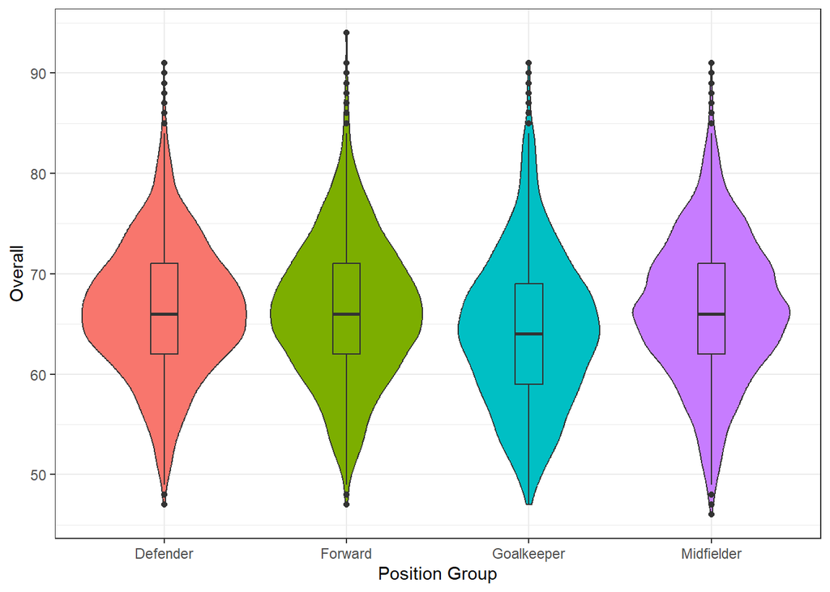

```r
ggplot(data_position_overall, aes(x = position, y = overall, fill = position)) +
  geom_violin() +
  geom_boxplot(width = 0.15) +
  labs(x = "Position Group", y = "Overall") +
  theme_bw() +
  theme(legend.position = "none")
```

```r
data_position_overall=data_position_overall[sample(nrow(train_data),10000),]
```

```r
set.seed(56)
library(lmPerm)
out_aov_1 <- aovp(formula = overall ~ position, data = data_position_overall, perm = "Prob")
```

```
## [1] "Settings:  unique SS "
```

```r
summary(out_aov_1)
```

```
## Component 1 :
##               Df R Sum Sq R Mean Sq Iter  Pr(Prob)
## position1      3     4087   1362.33 5000 < 2.2e-16 ***
## Residuals   9996   478436     47.86
## ---
## Signif. codes:  0 '***' 0.001 '**' 0.01 '*' 0.05 '.' 0.1 ' ' 1
```

> p_value<2.2e-16<0.05 =>Đủ cơ sở để bác bỏ H0 nên ta kết luận có ít nhất 1 nhóm có trung bìnhh overall khác với các nhóm còn lại

### Kiểm tra sự cân bằng của dữ liệu

```r
set.seed(123)

data_numeric_with_position <- train_data%>%
  dplyr::select(position, where(is.numeric)) %>%
  mutate(position = factor(position))


position_table=with(data_numeric_with_position,table(position))
```

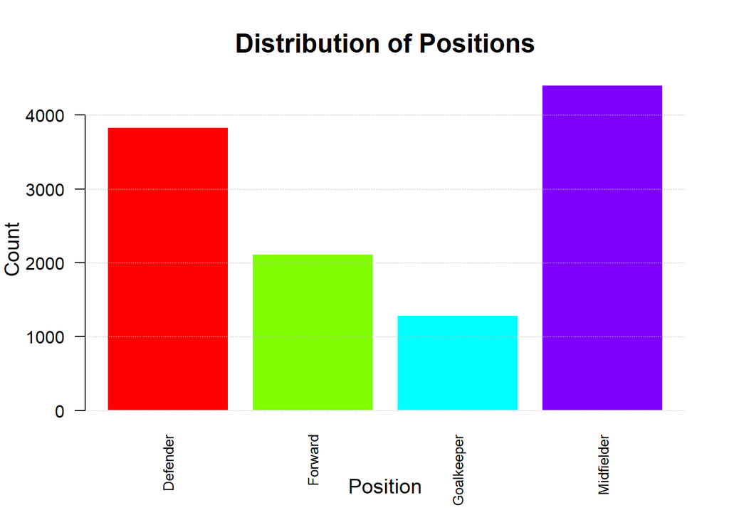

```r
# Vẽ biểu đồ từ bảng tần suất
barplot(
  position_table,
  main = "Distribution of Positions", # Tiêu đề biểu đồ
  xlab = "Position",                  # Nhãn trục X
  ylab = "Count",                     # Nhãn trục Y
  col = rainbow(length(position_table)),
  border = "white",
  las = 2,
  cex.names = 0.8,
  cex.main = 1.5,
  cex.lab = 1.2
)

grid(nx = NA, ny = NULL, col = "gray", lty = "dotted", lwd = 0.7)
```

> Dữ liệu không cân bằng nên ta dùng phương pháp SMOTE để cân bằng dữ liệu

```r
# Xóa phần dữ liệu khuyết
data_numeric_with_position <- na.omit(data_numeric_with_position)
```

```r
smote_themis_position_group <- smotenc(df = data_numeric_with_position,
                                       var = "position",
                                       k = 5,
                                       over_ratio = 1)
table(smote_themis_position_group$position)
```

```
##
##   Defender    Forward Goalkeeper Midfielder
##       4407       4407       4407       4407
```

###Phân loại:

> Dùng mô hình Multinominal logistic để phân loại Chọn các chỉ số quan trọng của các cầu thủ

```r
columns <- c("finishing", "positioning", "acceleration", "shot_power", "balance",
             "dribbling", "vision", "ball_control", "short_passing", "long_shots",
             "stamina", "marking", "interceptions", "strength",
             "heading_accuracy", "standing_tackle","crossing","agility","gk_handling", "gk_diving", "gk_kicking", "gk_positioning", "gk_reflexes")
```

```r
formula <- as.formula(paste("position ~", paste(columns, collapse = "+")))
out_mult=multinom(formula,data=smote_themis_position_group,maxit=200)
```

### Đánh giá mô hình

```r
pred_class=predict(out_mult,test_data,type="class")
conf_matrix=table(test_data$position,pred_class)
conf_matrix
```

```
##             pred_class
##              Defender Forward Goalkeeper Midfielder
##   Defender       1466       2          0        133
##   Forward           6     797          0        124
##   Goalkeeper        0       0        611          0
##   Midfielder      134     256          0       1464
```

```r
eval_multi_class <- function(x) {
  cc <- sum(diag(x))
  sc <- sum(x)
  pp <- colSums(x)
  tt <- rowSums(x)
  ##
  prec <- diag(x)/colSums(x)
  recall <- diag(x)/rowSums(x)
  macro_prec <- mean(prec)
  macro_recall <- mean(recall)
  macro_f1 <- 2 * macro_prec * macro_recall/(1/macro_prec + 1/macro_recall)
  acc <- cc/sc
  kap <- (cc * sc - sum(pp * tt))/(sc^2 - sum(pp * tt))
  return(list(Precision = prec, Recall = recall, Accuracy = acc, Kappa = kap,
              Macro_F1 = macro_f1))
}
eval_multi_class(conf_matrix)
```

```
## $Precision
##   Defender    Forward Goalkeeper Midfielder
##  0.9128269  0.7554502  1.0000000  0.8506682
##
## $Recall
##   Defender    Forward Goalkeeper Midfielder
##  0.9156777  0.8597627  1.0000000  0.7896440
##
## $Accuracy
## [1] 0.8688163
##
## $Kappa
## [1] 0.8164421
##
## $Macro_F1
## [1] 0.6942795
```

##2.Phân loại cầu thủ dựa trên khả năng phù hợp với các chiến thuật của đội bóng

> Nhóm 1: Hight Pressing (tập trung vào kĩ năng stamina và aggression)

> Nhóm 2: Fast Counter-Attack (tập trung vào kĩ năng acceleration và sprint_speed)

> Nhóm 3: Control Possession (tập trung vào kĩ năng long_passing,short_passing, ball_control và vision)

> Nhóm 4: Other

```r
data_clean=train_data
```

```r
# Tạo cột 'strategy' với các điều kiện cho từng nhóm chiến thuật
data_clean$strategy <- case_when(
  data_clean$stamina > 70 & data_clean$aggression > 70 ~ "High Pressing",  # Nhóm 1: High Pressing
  data_clean$acceleration > 70 & data_clean$sprint_speed > 70 ~ "Fast Counter-Attack",  # Nhóm 2: Fast Counter-Attack
  data_clean$long_passing > 70 & data_clean$short_passing > 70 & data_clean$ball_control > 70 & data_clean$vision > 70 ~ "Control Possession",  # Nhóm 3: Control Possession
  TRUE ~ "Other"  # Nhóm khác nếu không thỏa mãn các điều kiện trên
)
```

### A/B testing:

> Giả thuyết H0: các nhóm chiến thuật có trung bình value như nhau

> Đối thuyết H1: Ít nhất có một nhóm có trung bình value khác với những nhóm còn lại.

```r
data_strategy_value=data_clean|>dplyr::select(strategy,value)
data_strategy_value=data_strategy_value|>clean_names()
glimpse(data_strategy_value)
```

```
## Rows: 11,650
## Columns: 2
## $ strategy <chr> "Fast Counter-Attack", "Control Possession", "High Pressing",…
## $ value    <dbl> 4.100, 3.800, 3.200, 0.300, 1.800, 0.450, 0.140, 5.000, 0.375…
```

```r
data_strategy_value|>group_by(strategy)|>
  summarise(n=n(),mean=mean(value))
```

```
## # A tibble: 4 × 3
##   strategy                n  mean
##   <chr>               <int> <dbl>
## 1 Control Possession    271  8.53
## 2 Fast Counter-Attack  3045  2.99
## 3 High Pressing        1617  5.34
## 4 Other                6717  1.22
```

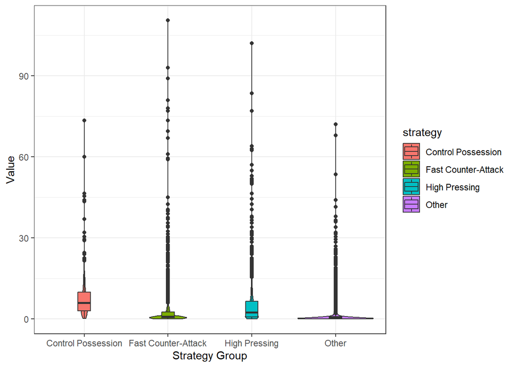

```r
ggplot(data_strategy_value, aes(x = strategy, y = value, fill = strategy)) +
  geom_violin() +
  geom_boxplot(width = 0.15) +
  labs(x = "Strategy Group", y = "Value") +
  theme_bw() +
  theme(legend.strategy = "none")
```

```r
set.seed(56)
data_strategy_value=data_strategy_value[sample(nrow(data), 10000), ]
library(lmPerm)
out_aov_1 <- aovp(formula = value ~ strategy, data = data_strategy_value, perm = "Prob")
```

```
## [1] "Settings:  unique SS "
```

```r
summary(out_aov_1)
```

```
## Component 1 :
##               Df R Sum Sq R Mean Sq Iter  Pr(Prob)
## strategy1      3    20999    6999.5 5000 < 2.2e-16 ***
## Residuals   7010   222230      31.7
## ---
## Signif. codes:  0 '***' 0.001 '**' 0.01 '*' 0.05 '.' 0.1 ' ' 1
```

> p_value<2.2e-16<0.05 =>Đủ cơ sở để bác bỏ H0 nên ta kết luận có ít nhất 1 nhóm có trung bình value khác với các nhóm còn lại

###Kiểm tra sự cân bằng của dữ liệu

```r
set.seed(123)

data_numeric_with_strategy <- data_clean %>%
  dplyr::select(strategy, where(is.numeric)) %>%
  mutate(strategy = factor(strategy))


with(data_numeric_with_strategy,table(strategy))
```

```
## strategy
##  Control Possession Fast Counter-Attack       High Pressing               Other
##                 271                3045                1617                6717
```

> Dữ liệu không cân bằng nên ta dùng phương pháp SMOTE để cân bằng dữ liệu

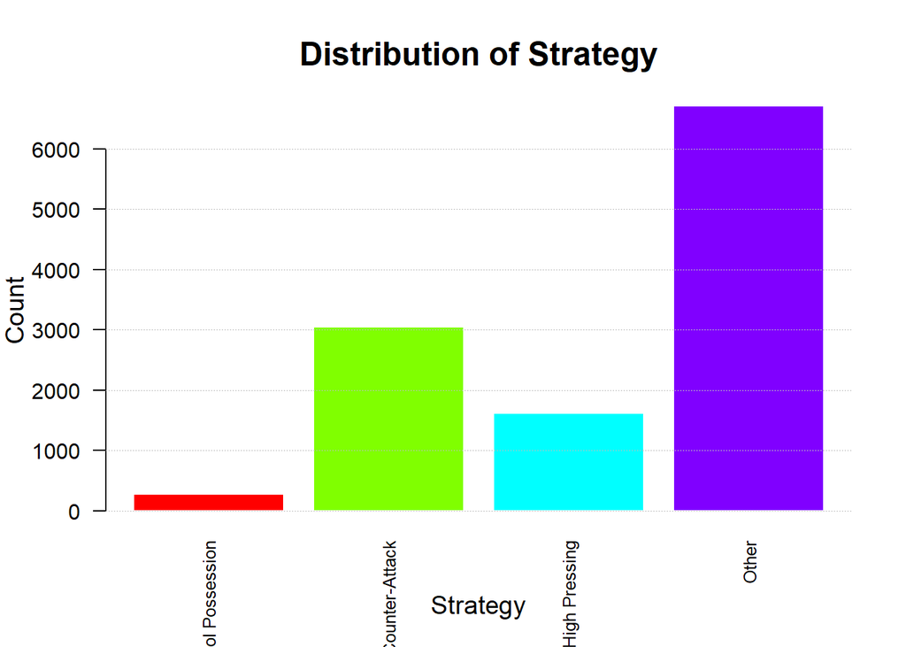

```r
# Vẽ biểu đồ từ bảng tần suất
strategy_table=with(data_numeric_with_strategy,table(strategy))
barplot(
  strategy_table,
  main = "Distribution of Strategy", # Tiêu đề biểu đồ
  xlab = "Strategy",                  # Nhãn trục X
  ylab = "Count",                     # Nhãn trục Y
  col = rainbow(length(strategy_table)),
  border = "white",
  las = 2,
  cex.names = 0.8,
  cex.main = 1.5,
  cex.lab = 1.2
)

grid(nx = NA, ny = NULL, col = "gray", lty = "dotted", lwd = 0.7)
```

```r
# Xóa phần dữ liệu khuyết
data_numeric_with_strategy <- na.omit(data_numeric_with_strategy)
```

```r
smote_themis_strategy_group <- smotenc(df = data_numeric_with_strategy,
                                       var = "strategy",
                                       k = 5,
                                       over_ratio = 1)
table(smote_themis_strategy_group$strategy)
```

```
##
##  Control Possession Fast Counter-Attack       High Pressing               Other
##                6717                6717                6717                6717
```

###Phân loại

> Dùng mô hình Multinominal logistic để phân loại Chọn các chỉ số stamina,aggression, acceleration,sprint_speed,long_passing,short_passing, ball_control và vision

```r
columns <- c("stamina","aggression", "acceleration","sprint_speed","long_passing","short_passing", "ball_control", "vision")
```

```r
formula <- as.formula(paste("strategy ~", paste(columns, collapse = "+")))
out_mult=multinom(formula,data=smote_themis_strategy_group,maxit=200)
```

### Đánh giá mô hình

```r
pred_class=predict(out_mult,data_clean,type="class")
conf_matrix=table(data_clean$strategy,pred_class)
conf_matrix
```

```
##                      pred_class
##                       Control Possession Fast Counter-Attack High Pressing
##   Control Possession                 257                   1            13
##   Fast Counter-Attack                 65                2786           127
##   High Pressing                       59                  76          1420
##   Other                              174                 279           376
##                      pred_class
##                       Other
##   Control Possession      0
##   Fast Counter-Attack    67
##   High Pressing          62
##   Other                5888
```

```r
eval_multi_class <- function(x) {
  cc <- sum(diag(x))
  sc <- sum(x)
  pp <- colSums(x)
  tt <- rowSums(x)
  ##
  prec <- diag(x)/colSums(x)
  recall <- diag(x)/rowSums(x)
  macro_prec <- mean(prec)
  macro_recall <- mean(recall)
  macro_f1 <- 2 * macro_prec * macro_recall/(1/macro_prec + 1/macro_recall)
  acc <- cc/sc
  kap <- (cc * sc - sum(pp * tt))/(sc^2 - sum(pp * tt))
  return(list(Precision = prec, Recall = recall, Accuracy = acc, Kappa = kap,
              Macro_F1 = macro_f1))
}
eval_multi_class(conf_matrix)
```

```
## $Precision
##  Control Possession Fast Counter-Attack       High Pressing               Other
##           0.4630631           0.8866964           0.7334711           0.9785607
##
## $Recall
##  Control Possession Fast Counter-Attack       High Pressing               Other
##           0.9483395           0.9149425           0.8781694           0.8765818
##
## $Accuracy
## [1] 0.8884979
##
## $Kappa
## [1] 0.816472
##
## $Macro_F1
## [1] 0.5740917
```

##3. Phân loại theo chân thuận:

> Nhóm 1: Các cầu thủ thuận chân phải

> Nhóm 2: Các cầu thủ thuận chân trái

```r
data_clean_2=train_data
```

###Kiểm tra dữ liệu có cân bằng không

```r
with(data_clean_2, table(preferred_foot))
```

```
## preferred_foot
##  Left Right
##  2695  8955
```

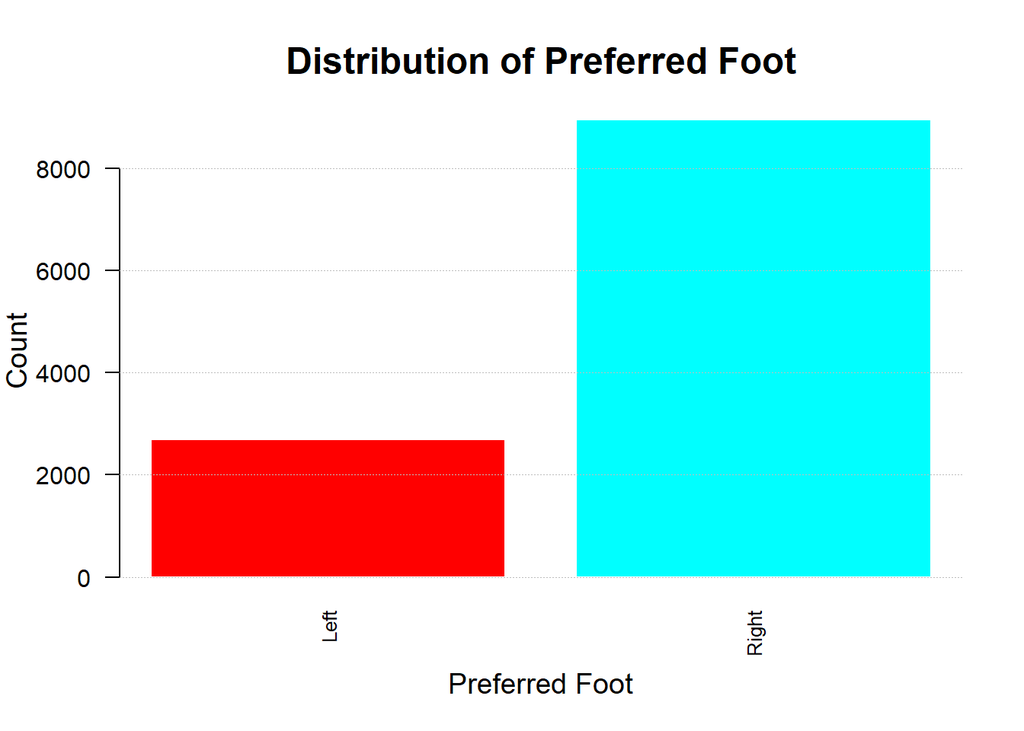

```r
# Vẽ biểu đồ từ bảng tần suất
preferred_foot_table=with(data_clean_2,table(preferred_foot))
barplot(
  preferred_foot_table,
  main = "Distribution of Preferred Foot", # Tiêu đề biểu đồ
  xlab = "Preferred Foot",                  # Nhãn trục X
  ylab = "Count",                     # Nhãn trục Y
  col = rainbow(length(preferred_foot_table)),
  border = "white",
  las = 2,
  cex.names = 0.8,
  cex.main = 1.5,
  cex.lab = 1.2
)

grid(nx = NA, ny = NULL, col = "gray", lty = "dotted", lwd = 0.7)
```

> Dữ liệu không cân bằng:

> Sử dụng phương pháp under_sampling để chọn ngẫu nhiên các quan sát trong nhóm lớn (majority group) sao cho số lượng phần tử trong nhóm này sẽ bằng với nhóm nhỏ (minority group)

```r
under_sampling_2c <- function(data, name_class){
new_data <- data
class_fact <- as.factor(data[, name_class])
data_split <- split(data, class_fact)
n_class <- sapply(data_split, FUN = nrow)
n_minor <- min(n_class)
n_major <- max(n_class)
id_major_class <- which.max(n_class)
id_minor_class <- which.min(n_class)
id_major <- sample(1:n_major, size = n_minor, replace = FALSE)
new_data_major <- data_split[[id_major_class]][id_major, ]
new_data <- rbind(data_split[[id_minor_class]], new_data_major)
return(new_data)
}
```

```r
set.seed(234)
data_clean_2 <- as.data.frame(data_clean_2)
preferred_foot_under <- under_sampling_2c(data_clean_2, "preferred_foot")
with(preferred_foot_under, table(preferred_foot))
```

```
## preferred_foot
##  Left Right
##  2695  2695
```

> Chuyển cột preferred_foot về numeric

```r
preferred_foot_under <- preferred_foot_under %>%
  mutate(
    preferred_foot = case_when(
      preferred_foot == "Right" ~ 1,
      preferred_foot == "Left" ~ 0,
      TRUE ~ NA_real_  # Nếu không khớp với điều kiện nào
  )
)
```

```r
data_clean_2 <- data_clean_2 %>%
  mutate(
    preferred_foot = case_when(
      preferred_foot == "Right" ~ 1,
      preferred_foot == "Left" ~ 0,
      TRUE ~ NA_real_  # Nếu không khớp với điều kiện nào
  )
  )
```

###Phân loại >Xây dựng mô hình phân loại logistic

```r
out_md <- glm(formula = preferred_foot ~ weak_foot + dribbling + ball_control+finishing+crossing+agility+strength+positioning+short_passing+long_passing, data =preferred_foot_under,
family = binomial)
```

```r
summary(out_md)
```

```
##
## Call:
## glm(formula = preferred_foot ~ weak_foot + dribbling + ball_control +
##     finishing + crossing + agility + strength + positioning +
##     short_passing + long_passing, family = binomial, data = preferred_foot_under)
##
## Coefficients:
##                 Estimate Std. Error z value Pr(>|z|)
## (Intercept)   -2.044e-01  2.660e-01  -0.768  0.44234
## weak_foot      3.935e-01  4.697e-02   8.377  < 2e-16 ***
## dribbling     -1.775e-02  5.823e-03  -3.048  0.00231 **
## ball_control   2.862e-03  7.166e-03   0.399  0.68966
## finishing      1.236e-02  3.322e-03   3.719  0.00020 ***
## crossing      -5.200e-02  3.594e-03 -14.470  < 2e-16 ***
## agility        3.588e-03  3.294e-03   1.089  0.27604
## strength       1.516e-03  2.606e-03   0.582  0.56077
## positioning    9.756e-03  4.322e-03   2.257  0.02400 *
## short_passing  2.046e-02  7.014e-03   2.917  0.00353 **
## long_passing  -3.288e-05  4.684e-03  -0.007  0.99440
## ---
## Signif. codes:  0 '***' 0.001 '**' 0.01 '*' 0.05 '.' 0.1 ' ' 1
##
## (Dispersion parameter for binomial family taken to be 1)
##
##     Null deviance: 7472.1  on 5389  degrees of freedom
## Residual deviance: 6901.8  on 5379  degrees of freedom
## AIC: 6923.8
##
## Number of Fisher Scoring iterations: 4
```

> Sử dụng dự đoán 10 cầu thủ đầu tiên của data

```r
test=head(test_data, 10)
```

```r
test$preferred_foot
```

```
##  [1] "Right" "Right" "Right" "Right" "Right" "Right" "Right" "Right" "Right"
## [10] "Left"
```

```r
pred_prob <- predict(out_md, newdata = test, type = "response")
ifelse(pred_prob > 0.5, "Right", "Left")
```

```
##       3       8      12      19      22      24      28      29      34      35
## "Right" "Right"  "Left" "Right" "Right" "Right" "Right"  "Left"  "Left"  "Left"
```

###Đánh giá mô hình phân loại nhị phân

> Tính xác suất dự đoán cho tất cả các quan sát trong dữ liệu.

```r
prob_pred_dt<- predict(out_md,newdata = test_data, type = "response")
```

> Chọn ngưỡng threshold mặc định là 0.5

```r
threshold <- 0.5  # Ngưỡng mặc định
predicted_class <- ifelse(prob_pred_dt >= threshold, 1, 0)
```

```r
test_data$preferred_foot <- ifelse(test_data$preferred_foot == "Right", 1, 0)
```

```r
conf_matrix <- confusionMatrix(as.factor(predicted_class), as.factor(test_data$preferred_foot))
print(conf_matrix)
```

```
## Confusion Matrix and Statistics
##
##           Reference
## Prediction    0    1
##          0  750 1483
##          1  375 2385
##
##                Accuracy : 0.6279
##                  95% CI : (0.6143, 0.6413)
##     No Information Rate : 0.7747
##     P-Value [Acc > NIR] : 1
##
##                   Kappa : 0.2099
##
##  Mcnemar's Test P-Value : <2e-16
##
##             Sensitivity : 0.6667
##             Specificity : 0.6166
##          Pos Pred Value : 0.3359
##          Neg Pred Value : 0.8641
##              Prevalence : 0.2253
##          Detection Rate : 0.1502
##    Detection Prevalence : 0.4472
##       Balanced Accuracy : 0.6416
##
##        'Positive' Class : 0
##
```

```r
library(pROC)
out_roc <- roc(test_data$preferred_foot , prob_pred_dt)
```

> Ước lượng AUC

```r
out_roc$auc
```

```
## Area under the curve: 0.6957
```

> Khoảng tin cậy 95% cho AUC

```r
ci.auc(out_roc, conf.level = 0.95)
```

```
## 95% CI: 0.6776-0.7138 (DeLong)
```

> Vẽ đường cong ROC ước lượng

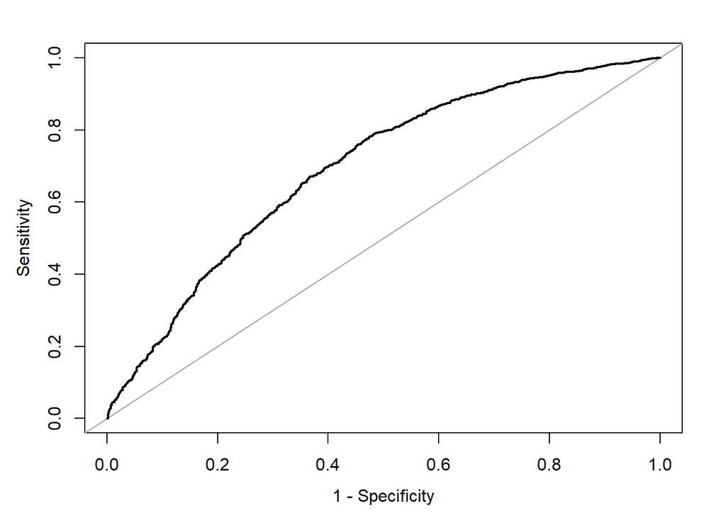

```r
plot(out_roc, legacy.axes = TRUE, asp = 0)
```

> Đường cong ROC nằm trên bên trái đường tham chiếu nhưng không quá cao nhưng mô hình vẫn có khả năng dự đoán phân loại có tính chính xác chấp nhận được

##Tìm ngưỡng threshold tối ưu

> Youden index giúp tối ưu hóa sự kết hợp giữa sensitivity và specificity

```r
out_youd <- coords(out_roc, "best", ret = c("threshold", "specificity", "sensitivity"),
best.method = "youden")
print(out_youd)
```

```
##   threshold specificity sensitivity
## 1 0.4304604   0.5262222   0.7807653
```

```r
predicted_class <- ifelse(prob_pred_dt >= out_youd$threshold, 1, 0)
conf_matrix <- confusionMatrix(as.factor(predicted_class), as.factor(test_data$preferred_foot))
print(conf_matrix)
```

```
## Confusion Matrix and Statistics
##
##           Reference
## Prediction    0    1
##          0  592  848
##          1  533 3020
##
##                Accuracy : 0.7234
##                  95% CI : (0.7108, 0.7358)
##     No Information Rate : 0.7747
##     P-Value [Acc > NIR] : 1
##
##                   Kappa : 0.2793
##
##  Mcnemar's Test P-Value : <2e-16
##
##             Sensitivity : 0.5262
##             Specificity : 0.7808
##          Pos Pred Value : 0.4111
##          Neg Pred Value : 0.8500
##              Prevalence : 0.2253
##          Detection Rate : 0.1186
##    Detection Prevalence : 0.2884
##       Balanced Accuracy : 0.6535
##
##        'Positive' Class : 0
##
```

> Closest top left tìm ngưỡng sao cho điểm trên ROC curve gần nhất với điểm lý tưởng (1, 1) - là điểm có sensitivity và specificity tối đa

```r
out_clost <- coords(out_roc, "best", ret = c("threshold", "specificity", "sensitivity"),
best.method = "closest.topleft")
print(out_clost)
```

```
##   threshold specificity sensitivity
## 1 0.4792016   0.6337778   0.6701138
```

```r
predicted_class <- ifelse(prob_pred_dt >= out_clost$threshold, 1, 0)
conf_matrix <- confusionMatrix(as.factor(predicted_class), as.factor(test_data$preferred_foot))
print(conf_matrix)
```

```
## Confusion Matrix and Statistics
##
##           Reference
## Prediction    0    1
##          0  713 1276
##          1  412 2592
##
##                Accuracy : 0.6619
##                  95% CI : (0.6486, 0.6751)
##     No Information Rate : 0.7747
##     P-Value [Acc > NIR] : 1
##
##                   Kappa : 0.2388
##
##  Mcnemar's Test P-Value : <2e-16
##
##             Sensitivity : 0.6338
##             Specificity : 0.6701
##          Pos Pred Value : 0.3585
##          Neg Pred Value : 0.8628
##              Prevalence : 0.2253
##          Detection Rate : 0.1428
##    Detection Prevalence : 0.3984
##       Balanced Accuracy : 0.6519
##
##        'Positive' Class : 0
##
```

> Phân loại Naive Bayes:

```r
out_nb <- naiveBayes(formula = preferred_foot ~ weak_foot + dribbling + ball_control+finishing+crossing+agility+strength+positioning+short_passing+long_passing,
data = preferred_foot_under)
```

> Đánh giá mô hình phân loại nhị phân

> Dự đoán xác suất cho lớp 1 (chân phải) từ mô hình Naive Bayes. Dữ liệu trả về sẽ có 2 cột, và [ , 2] sẽ chọn cột xác suất của lớp 1.

```r
pred_prob <- predict(out_nb, newdata = test_data, type = "raw")[, 2]
out_roc <- roc(test_data$preferred_foot, pred_prob)
```

> Chọn ngưỡng threshold mặc định là 0.5

```r
threshold <- 0.5  # Ngưỡng mặc định
predicted_class <- ifelse(pred_prob >= threshold, 1, 0)
```

```r
predicted_class <- factor(predicted_class, levels = c(0, 1))
test_data$preferred_foot <- factor(test_data$preferred_foot, levels = c(0, 1))
conf_matrix <- confusionMatrix(predicted_class, test_data$preferred_foot)
```

```r
print(conf_matrix)
```

```
## Confusion Matrix and Statistics
##
##           Reference
## Prediction    0    1
##          0  900 2629
##          1  225 1239
##
##                Accuracy : 0.4284
##                  95% CI : (0.4146, 0.4423)
##     No Information Rate : 0.7747
##     P-Value [Acc > NIR] : 1
##
##                   Kappa : 0.0685
##
##  Mcnemar's Test P-Value : <2e-16
##
##             Sensitivity : 0.8000
##             Specificity : 0.3203
##          Pos Pred Value : 0.2550
##          Neg Pred Value : 0.8463
##              Prevalence : 0.2253
##          Detection Rate : 0.1803
##    Detection Prevalence : 0.7068
##       Balanced Accuracy : 0.5602
##
##        'Positive' Class : 0
##
```

```r
out_roc$auc
```

```
## Area under the curve: 0.6267
```

> Khoảng tin cậy 95% cho AUC

```r
ci.auc(out_roc, conf.level = 0.95)
```

```
## 95% CI: 0.6079-0.6454 (DeLong)
```

> Vẽ đường cong ROC ước lượng

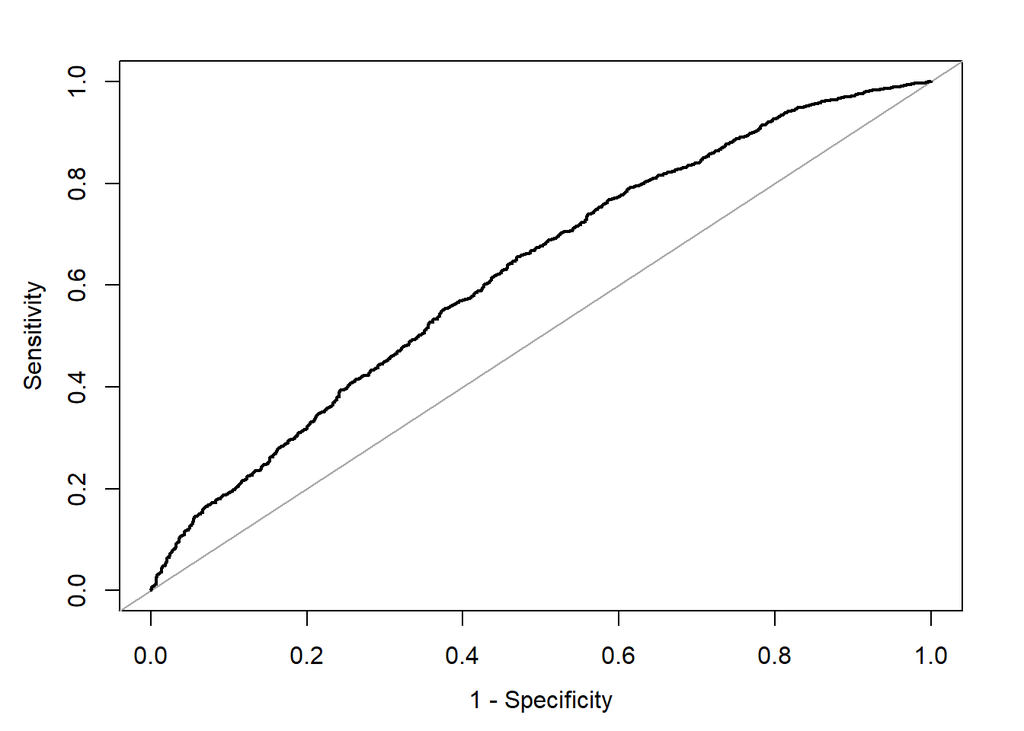

```r
plot(out_roc, legacy.axes = TRUE, asp = 0)
```

> Đường cong ROC nằm trên bên trái đường tham chiếu nhưng không cao bằng mô hình phân loại logistic nhưng mô hình vẫn có khả năng dự đoán phân loại có tính chính xác chấp nhận được

## 4.Danh tiếng quốc tế của cầu thủ

### Chuẩn hoá cho các cột có giá trị định tính.

```r
data <- data %>%
  mutate(
    preferred_foot = as.factor(preferred_foot),
    #international_reputation = as.factor(international_reputation),
    position = as.factor(position),
    body_type = as.factor(body_type),
    skill_moves = as.factor(skill_moves),
    weak_foot = as.factor(weak_foot)
  )
```

```r
data_reputation<-data
table(data_reputation$international_reputation)
```

```
##
##     1     2     3     4     5
## 15141  1154   293    49     6
```

### A/B Testing

```r
data_reputation|>group_by(international_reputation)|>
  summarise(n=n(),mean=mean(wage))
```

```
## # A tibble: 5 × 3
##   international_reputation     n    mean
##                      <int> <int>   <dbl>
## 1                        1 15141 0.00584
## 2                        2  1154 0.0320
## 3                        3   293 0.0832
## 4                        4    49 0.173
## 5                        5     6 0.31
```

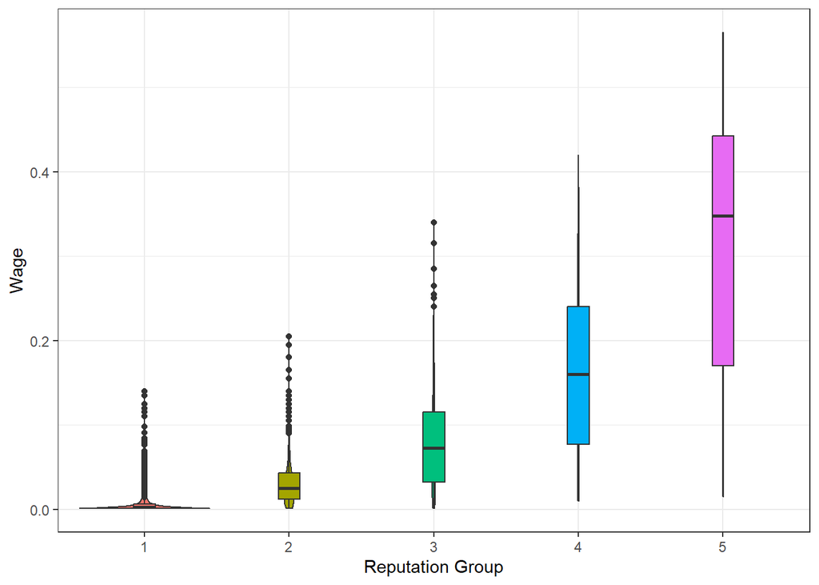

```r
ggplot(data_reputation, aes(x = as.factor(international_reputation), y = wage, fill = as.factor(international_reputation))) +
  geom_violin() +
  geom_boxplot(width = 0.15, position = position_dodge(width = 0.9)) +
  labs(x = "Reputation Group", y = "Wage") +
  theme_bw() +
  theme(legend.position = "none")
```

```r
data_repu=data_reputation[sample(nrow(data), 10000), ]
```

```r
set.seed(56)
out_aov_1 <- aovp(formula = overall ~ international_reputation,
                  data = data_repu,
                  perm = "Prob")
```

```
## [1] "Settings:  unique SS : numeric variables centered"
```

```r
summary(out_aov_1)
```

```
## Component 1 :
##                            Df R Sum Sq R Mean Sq Iter  Pr(Prob)
## international_reputation    1   121548    121548 5000 < 2.2e-16 ***
## Residuals                9998   369320        37
## ---
## Signif. codes:  0 '***' 0.001 '**' 0.01 '*' 0.05 '.' 0.1 ' ' 1
```

> - p_value<2.2e-16<0.05 =>Đủ cơ sở để bác bỏ H0 nên ta kết luận có ít nhất 1 nhóm có trung bìnhh overall khác với các nhóm còn lại

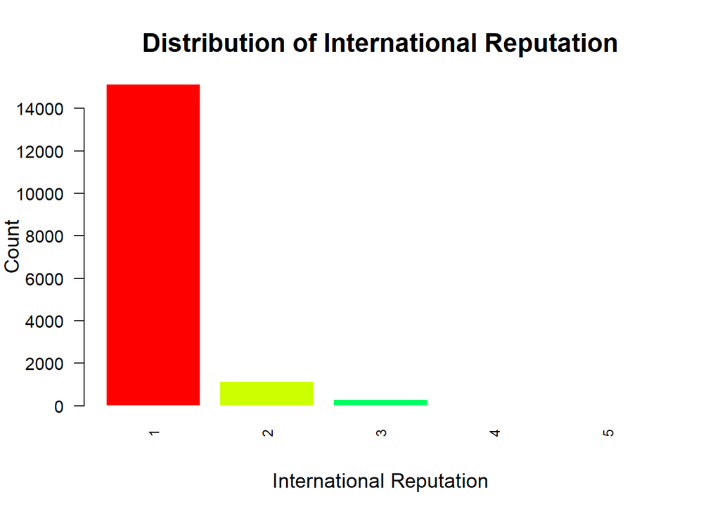

```r
#Vẽ biểu đồ cột
international_reputation_table=with(data_reputation,table(international_reputation))
barplot(
  international_reputation_table,
  main = "Distribution of International Reputation", # Tiêu đề biểu đồ
  xlab = "International Reputation",                  # Nhãn trục X
  ylab = "Count",                     # Nhãn trục Y
  col = rainbow(length(international_reputation_table)),
  border = "white",
  las = 2,
  cex.names = 0.8,
  cex.main = 1.5,
  cex.lab = 1.2
)
```

> ** Nhận xét:**
> - Cột international_reputation có 5 giá trị duy nhất từ 1 đến 5.Đây là các biến định tính.
> - Số lượng cầu thủ có danh tiếng quốc tế từ 1 đến 5 là không đồng đều.
> - Số lượng cầu thủ có danh tiếng quốc tế từ 1 đến 2 chiếm phần lớn trong khi số lượng cầu thủ có danh tiếng quốc tế từ 3 đến 5 chiếm phần rất nhỏ. -Cần phải xử lý dữ liệu để cân bằng số lượng cầu thủ có danh tiếng quốc tế từ 1 đến 5.

### Hồi quy logistic đa lớp

```r
data_reputation_2<-data
table(data_reputation_2$international_reputation)
```

```
##
##     1     2     3     4     5
## 15141  1154   293    49     6
```

```r
data_reputation_2$international_reputation <- factor(data_reputation_2$international_reputation)
```

```r
set.seed(123)
data_reputation_2 <- smotenc(
  df = data_reputation_2,
  var = "international_reputation",
  k = 5,
  over_ratio = 1
)
```

```r
table(data_reputation_2$international_reputation)
```

```
##
##     1     2     3     4     5
## 15141 15141 15141 15141 15141
```

```r
train_index <- sample(1:nrow(data_reputation_2), size = 0.8 * nrow(data_reputation_2))
train_data <- data_reputation_2[train_index, ]
test_data <- data_reputation_2[-train_index, ]
```

```r
selected_variables <- c("age", "overall", "potential", "value", "wage",
                        "height",
                        "weight", "short_passing", "volleys", "balance",
                        "shot_power", "jumping", "stamina", "aggression",
                        "composure", "release_clause")
```

```r
formula <- as.formula(paste("international_reputation ~", paste(selected_variables, collapse = "+")))

logistic_model=multinom(formula,data=train_data,maxit=200)
summary(logistic_model)
```

```
## Call:
## multinom(formula = formula, data = train_data, maxit = 200)
##
## Coefficients:
##   (Intercept)       age   overall   potential     value     wage      height
## 2   -48.24337 0.3003963 0.3886167 -0.07914821 0.4742319 51.40399  0.15149394
## 3  -117.81234 0.5649238 0.9476817  0.01490913 0.4337465 65.60984  0.26074319
## 4  -218.72907 1.1036887 1.7350520  0.32945945 0.3220349 68.75887  0.01073641
## 5  -403.44693 5.6295033 0.5569303  1.35769157 0.8022006 51.09035 -1.78243984
##         weight short_passing    volleys     balance    shot_power    jumping
## 2  0.003965409    0.02401266 0.02625259  0.02871854  0.0056835943 0.02130028
## 3 -0.025231825    0.01811268 0.06033758  0.02038323 -0.0089074263 0.04903645
## 4  0.050285889    0.04001945 0.14097435  0.02778377  0.0008384134 0.03683349
## 5  0.811527130    0.68127702 0.47889907 -0.52070901 -0.3503890771 0.22705983
##      stamina   aggression  composure release_clause
## 2 -0.0727387  0.018152032 0.03364355    -0.21966057
## 3 -0.1176064  0.010086264 0.15588195    -0.22342296
## 4 -0.1734273  0.001862282 0.10550401    -0.19883804
## 5 -0.3600184 -0.261723816 0.14571987     0.03292802
##
## Std. Errors:
##    (Intercept)        age    overall  potential      value         wage
## 2 0.0003206961 0.01113324 0.02015329 0.01826772 0.04886751 0.0005554539
## 3 0.0002971657 0.01585045 0.02893097 0.02584224 0.05115115 0.0013393062
## 4 0.0003191604 0.02239918 0.04224039 0.03754441 0.05213222 0.0014077042
## 5 0.0007838944 0.07789616 0.09135700 0.09372083 0.15199029 0.0012069192
##       height      weight short_passing     volleys     balance  shot_power
## 2 0.01287380 0.002870185   0.004270193 0.002721000 0.002950431 0.003369432
## 3 0.01843662 0.003803129   0.005938521 0.003655458 0.004278357 0.004596746
## 4 0.02636427 0.004784203   0.007455372 0.004642171 0.005660903 0.006082079
## 5 0.06514415 0.101876224   0.154693308 0.096385572 0.086735664 0.132845625
##       jumping     stamina  aggression   composure release_clause
## 2 0.002604872 0.003030841 0.002399442 0.004985599     0.02252751
## 3 0.003485343 0.004158081 0.003306245 0.007383559     0.02359082
## 4 0.004464605 0.005466931 0.004218102 0.010203169     0.02408683
## 5 0.072311010 0.146466217 0.149804416 0.069429309     0.07656727
##
## Residual Deviance: 41282.25
## AIC: 41418.25
```

```r
# Dự đoán lớp cho dữ liệu kiểm tra
pred_class_reputation <- predict(logistic_model, newdata = test_data, type = "class")
# Tạo confusion matrix
conf_matrix_reputation <- table(test_data$international_reputation, pred_class_reputation)
conf_matrix_reputation
```

```
##    pred_class_reputation
##        1    2    3    4    5
##   1 2636  327   13    0    0
##   2  215 2386  473    9    0
##   3    1  408 2160  446    0
##   4    0    0  360 2647    0
##   5    0    0    0    0 3060
```

```r
eval_multi_class(conf_matrix_reputation)
```

```
## $Precision
##         1         2         3         4         5
## 0.9242637 0.7644986 0.7185629 0.8533204 1.0000000
##
## $Recall
##         1         2         3         4         5
## 0.8857527 0.7739215 0.7164179 0.8802793 1.0000000
##
## $Accuracy
## [1] 0.8512648
##
## $Kappa
## [1] 0.8140668
##
## $Macro_F1
## [1] 0.6178205
```

> Loại bỏ các giá trị 3,4,5 của international_reputation

```r
data_reputation<- data %>%
  filter(!(international_reputation %in% c(3, 4, 5)))

table(data_reputation$international_reputation)
```

```
##
##     1     2
## 15141  1154
```

> Chuẩn hoá cho cột international_reputation

```r
data_reputation <- data_reputation %>%
  mutate(
    international_reputation = as.factor(international_reputation),
  )
```

```r
str(data_reputation$international_reputation)
```

```
##  Factor w/ 2 levels "1","2": 2 2 2 1 2 2 2 2 2 2 ...
```

> **Nhận xét**:
> - Cột international_reputation đã được chuyển thành factor.

> Sử dụng SMOTE để cân bằng dữ liệu

```r
data_reputation=na.omit(data_reputation)
```

```r
set.seed(26)
data_reputation <- smotenc(
  df = data_reputation,
  var = "international_reputation",
  k = 5,
  over_ratio = 1
)
```

```r
table(data_reputation$international_reputation)
```

```
##
##     1     2
## 15141 15141
```

```r
columns <- c("age", "overall", "potential", "value", "wage",
                     "international_reputation", "skill_moves",
                     "body_type", "position", "height","attacking_work_rate","defensive_work_rate",
                    "weight", "crossing", "finishing", "heading_accuracy", "short_passing",
                    "volleys", "dribbling", "curve", "fk_accuracy", "long_passing", "ball_control",
                    "acceleration", "sprint_speed", "agility", "reactions", "balance", "shot_power",
                    "jumping", "stamina", "strength", "long_shots", "aggression", "interceptions",
                    "positioning", "vision", "penalties", "composure", "marking", "standing_tackle",
                    "sliding_tackle","release_clause")
```

```r
data_reputation<-data_reputation %>%
  dplyr::select(all_of(columns))
```

```r
glimpse(data_reputation)
```

```
## Rows: 30,282
## Columns: 43
## $ age                      <dbl> 22, 23, 24, 23, 23, 29, 22, 23, 24, 23, 22, 2…
## $ overall                  <dbl> 86, 86, 86, 85, 85, 85, 84, 84, 84, 84, 84, 8…
## $ potential                <dbl> 92, 91, 90, 92, 90, 85, 88, 88, 88, 88, 90, 8…
## $ value                    <dbl> 61.0, 59.5, 41.5, 46.5, 50.5, 37.0, 34.0, 34.…
## $ wage                     <dbl> 0.195, 0.180, 0.125, 0.082, 0.073, 0.066, 0.1…
## $ international_reputation <fct> 2, 2, 2, 1, 2, 2, 2, 2, 2, 2, 2, 2, 2, 2, 2, …
## $ skill_moves              <fct> 4, 4, 1, 2, 4, 3, 2, 2, 2, 4, 2, 3, 4, 1, 1, …
## $ body_type                <fct> Lean, Lean, Normal, Normal, Normal, Lean, Nor…
## $ position                 <fct> Forward, Forward, Goalkeeper, Defender, Midfi…
## $ height                   <dbl> 72, 68, 74, 74, 75, 72, 74, 73, 74, 70, 77, 7…
## $ attacking_work_rate      <chr> "High", "High", "Medium", "Medium", "High", "…
## $ defensive_work_rate      <chr> "Medium", "Medium", "Medium", "High", "Medium…
## $ weight                   <dbl> 165, 141, 190, 176, 168, 163, 174, 176, 187, …
```

[output cut: 30 more lines]

### Hồi quy logistic

```r
set.seed(269)
train_index <- sample(1:nrow(data_reputation), size = 0.8 * nrow(data_reputation))

train_data <- data_reputation[train_index, ]
test_data <- data_reputation[-train_index, ]
```

```r
logistic_model<- glm(formula = international_reputation~., data = train_data,
family = binomial)
```

```r
summary(logistic_model)
```

```
##
## Call:
## glm(formula = international_reputation ~ ., family = binomial,
##     data = train_data)
##
## Coefficients: (1 not defined because of singularities)
##                             Estimate Std. Error z value Pr(>|z|)
## (Intercept)               -4.629e+01  2.183e+00 -21.206  < 2e-16 ***
## age                        2.700e-01  1.325e-02  20.374  < 2e-16 ***
## overall                    3.595e-01  2.386e-02  15.071  < 2e-16 ***
## potential                 -9.926e-02  2.025e-02  -4.902 9.47e-07 ***
## value                      5.061e-01  5.135e-02   9.854  < 2e-16 ***
## wage                       4.511e+01  2.867e+00  15.735  < 2e-16 ***
## skill_moves2              -1.641e+00  4.098e-01  -4.005 6.20e-05 ***
## skill_moves3              -1.407e+00  4.372e-01  -3.217 0.001294 **
## skill_moves4              -1.788e+00  4.471e-01  -3.999 6.37e-05 ***
## skill_moves5              -8.765e-01  6.653e-01  -1.317 0.187691
## body_typeNormal           -3.095e-01  6.425e-02  -4.817 1.46e-06 ***
## body_typeStocky           -1.228e+00  1.306e-01  -9.403  < 2e-16 ***
## positionForward           -2.165e-01  1.557e-01  -1.391 0.164283
## positionGoalkeeper                NA         NA      NA       NA
## positionMidfielder        -4.169e-01  1.053e-01  -3.960 7.48e-05 ***
## height                     1.195e-01  2.474e-02   4.830 1.37e-06 ***
## attacking_work_rateLow     1.644e-01  1.512e-01   1.087 0.276850
## attacking_work_rateMedium  4.062e-01  6.756e-02   6.013 1.83e-09 ***
## defensive_work_rateLow     2.870e-01  1.181e-01   2.429 0.015126 *
## defensive_work_rateMedium  2.819e-01  7.177e-02   3.929 8.54e-05 ***
## weight                     1.430e-02  3.476e-03   4.112 3.92e-05 ***
## crossing                   1.696e-02  4.130e-03   4.106 4.03e-05 ***
## finishing                 -1.795e-02  4.821e-03  -3.723 0.000197 ***
## heading_accuracy           6.442e-04  4.107e-03   0.157 0.875344
## short_passing              4.853e-02  7.359e-03   6.594 4.27e-11 ***
## volleys                    4.472e-02  4.031e-03  11.093  < 2e-16 ***
## dribbling                 -8.796e-03  6.774e-03  -1.298 0.194122
## curve                      1.534e-02  4.075e-03   3.764 0.000167 ***
## fk_accuracy               -1.221e-02  3.453e-03  -3.535 0.000408 ***
## long_passing              -8.335e-04  5.137e-03  -0.162 0.871098
## ball_control              -1.887e-02  8.191e-03  -2.304 0.021210 *
## acceleration               8.816e-04  5.658e-03   0.156 0.876174
## sprint_speed              -5.347e-03  5.256e-03  -1.017 0.309024
```

[output cut: 13 more lines]

```
## composure                  4.374e-02  5.293e-03   8.263  < 2e-16 ***
## marking                   -2.092e-03  3.775e-03  -0.554 0.579426
## standing_tackle            2.183e-03  6.488e-03   0.336 0.736553
## sliding_tackle            -1.054e-02  6.203e-03  -1.699 0.089306 .
## release_clause            -2.327e-01  2.361e-02  -9.855  < 2e-16 ***
## ---
## Signif. codes:  0 '***' 0.001 '**' 0.01 '*' 0.05 '.' 0.1 ' ' 1
##
## (Dispersion parameter for binomial family taken to be 1)
##
##     Null deviance: 33583  on 24224  degrees of freedom
## Residual deviance: 10203  on 24175  degrees of freedom
## AIC: 10303
##
## Number of Fisher Scoring iterations: 7
```

*Nhận xét* >- Biến international_reputation gần như có thể giải thích được bởi các biến wage

```r
pred_prob <- predict(logistic_model, newdata = test_data, type = "response")

test_data$predicted_class<-ifelse(pred_prob > 0.5, 2, 1)
```

```r
set.seed(153)
test <- test_data[sample(nrow(test_data), 20), ]
# In hai cột predicted_class và international
print(test[, c("predicted_class", "international_reputation")])
```

```
##       predicted_class international_reputation
## 16485               2                        2
## 554                 2                        2
## 2874                2                        1
## 18717               2                        2
## 13341               1                        1
## 4077                2                        1
## 25098               2                        2
## 25732               2                        2
## 27192               2                        2
## 3496                1                        1
## 28490               2                        2
## 29518               2                        2
## 2519                1                        1
## 27242               2                        2
## 14345               1                        1
## 17454               2                        2
## 29818               1                        2
## 30158               1                        2
## 24581               2                        2
## 24799               2                        2
```

```r
conf_matrix <- confusionMatrix(as.factor(test_data$predicted_class), as.factor(test_data$international_reputation))
print(conf_matrix)
```

```
## Confusion Matrix and Statistics
##
##           Reference
## Prediction    1    2
##          1 2702  193
##          2  322 2840
##
##                Accuracy : 0.915
##                  95% CI : (0.9077, 0.9219)
##     No Information Rate : 0.5007
##     P-Value [Acc > NIR] : < 2.2e-16
##
##                   Kappa : 0.8299
##
##  Mcnemar's Test P-Value : 1.697e-08
##
##             Sensitivity : 0.8935
##             Specificity : 0.9364
##          Pos Pred Value : 0.9333
##          Neg Pred Value : 0.8982
##              Prevalence : 0.4993
##          Detection Rate : 0.4461
##    Detection Prevalence : 0.4780
##       Balanced Accuracy : 0.9149
##
##        'Positive' Class : 1
##
```

```r
library(pROC)
# Tính toán AUC
out_roc <- roc(test_data$international_reputation, pred_prob)
print(out_roc$auc)
```

```
## Area under the curve: 0.9686
```

```r
ci.auc(out_roc, conf.level = 0.95)
```

```
## 95% CI: 0.9645-0.9726 (DeLong)
```

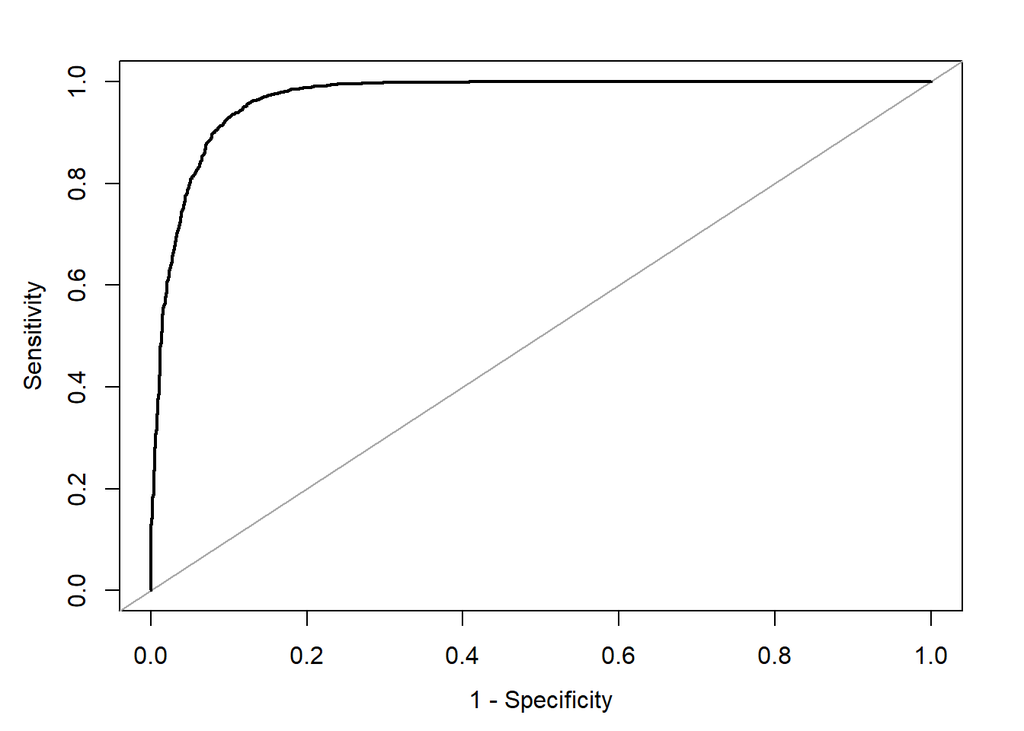

```r
plot(out_roc, legacy.axes = TRUE, asp = 0)
```

```r
out_youd <- coords(out_roc, "best", ret = c("threshold", "specificity", "sensitivity"),
best.method = "youden")
print(out_youd)
```

```
##   threshold specificity sensitivity
## 1 0.4024343   0.8716931   0.9610946
```

```r
out_clost <- coords(out_roc, "best", ret = c("threshold", "specificity", "sensitivity"),
best.method = "closest.topleft")
print(out_clost)
```

```
##   threshold specificity sensitivity
## 1  0.528847    0.901455   0.9287834
```

```r
pred_prob <- predict(logistic_model, newdata = test_data, type = "response")
test_data$predicted_class<-ifelse(pred_prob> out_clost$threshold, 2, 1)
```

```r
# In hai cột predicted_class và international
print(test[, c("predicted_class", "international_reputation")])
```

```
##       predicted_class international_reputation
## 16485               2                        2
## 554                 2                        2
## 2874                2                        1
## 18717               2                        2
## 13341               1                        1
## 4077                2                        1
## 25098               2                        2
## 25732               2                        2
## 27192               2                        2
## 3496                1                        1
## 28490               2                        2
## 29518               2                        2
## 2519                1                        1
## 27242               2                        2
## 14345               1                        1
## 17454               2                        2
## 29818               1                        2
## 30158               1                        2
## 24581               2                        2
## 24799               2                        2
```

```r
conf_matrix <- confusionMatrix(as.factor(test_data$predicted_class), as.factor(test_data$international_reputation))
print(conf_matrix)
```

```
## Confusion Matrix and Statistics
##
##           Reference
## Prediction    1    2
##          1 2726  216
##          2  298 2817
##
##                Accuracy : 0.9151
##                  95% CI : (0.9078, 0.922)
##     No Information Rate : 0.5007
##     P-Value [Acc > NIR] : < 2.2e-16
##
##                   Kappa : 0.8303
##
##  Mcnemar's Test P-Value : 0.0003532
##
##             Sensitivity : 0.9015
##             Specificity : 0.9288
##          Pos Pred Value : 0.9266
##          Neg Pred Value : 0.9043
##              Prevalence : 0.4993
##          Detection Rate : 0.4501
##    Detection Prevalence : 0.4857
##       Balanced Accuracy : 0.9151
##
##        'Positive' Class : 1
##
```

## 6.Phân loại cầu thủ theo khả năng di chuyển khi tấn công và phòng thủ

```r
cat("Number of unique attack: ", unique(data$attacking_work_rate))
```

```
## Number of unique attack:  Medium High Low
```

```r
cat("Number of unique defense: ", unique(data$defensive_work_rate))
```

```
## Number of unique defense:  Medium Low High
```

- Có 3 giá trị duy nhất cho attacking_work_rate và defensive_work_rate là “High”, “Medium”, “Low”.
- Ta sẽ chuyển đổi giá trị cho attacking_work_rate và defensive_work_rate.

```r
table(data$attacking_work_rate)
```

```
##
##   High    Low Medium
##   4438    845  11360
```

```r
table(data$defensive_work_rate)
```

```
##
##   High    Low Medium
##   2907   1418  12318
```

**Nhận xét** > >- Các biến đang có sự chênh lệch khá lớn do đó ta cần phải xử lý trước khi thực hiện việc phân loại. Cụ thể phương pháp được sử dụng cho trường hợp này là SMOTE (Synthetic Minority Over-sampling Technique) để tăng cường mẫu cho lớp thiểu số.

```r
library(dplyr)
# Chuyển đổi các giá trị "High", "Medium", "Low" chuyển thành factor
data$attacking_work_rate <- factor(data$attacking_work_rate, levels = c("High", "Medium", "Low"))
data$defensive_work_rate <- factor(data$defensive_work_rate, levels = c("High", "Medium", "Low"))
```

```r
# Kiểm tra lại kiểu dữ liệu của các cột
str(data$attacking_work_rate)
```

```
##  Factor w/ 3 levels "High","Medium",..: 2 1 1 2 1 1 1 1 1 2 ...
```

```r
str(data$defensive_work_rate)
```

```
##  Factor w/ 3 levels "High","Medium",..: 2 3 2 2 1 2 1 2 2 2 ...
```

### Tấn công

#### A/B Testing

> - Giả thuyết H0:các nhóm cầu thủ có cùng xu hướng di chuyển thì có trung bình overall như nhau.
> - Đối thuyết H1: Ít nhất có một nhóm có trung bình overall khác với những nhóm còn lại.

```r
set.seed(123)
# Lựa chọn các cột cần thiết để tạo ra một data frame mới
data_new_attack <- data[, sapply(data, function(col) is.numeric(col) || is.factor(col))]
glimpse(data_new_attack)
```

```
## Rows: 16,643
## Columns: 52
## $ id                       <int> 158023, 20801, 190871, 193080, 192985, 183277…
## $ age                      <int> 31, 33, 26, 27, 27, 27, 32, 31, 32, 25, 29, 2…
## $ overall                  <int> 94, 94, 92, 91, 91, 91, 91, 91, 91, 90, 90, 9…
## $ potential                <int> 94, 94, 93, 93, 92, 91, 91, 91, 91, 93, 90, 9…
## $ value                    <dbl> 110.5, 77.0, 118.5, 72.0, 102.0, 93.0, 67.0, …
## $ wage                     <dbl> 0.565, 0.405, 0.290, 0.260, 0.355, 0.340, 0.4…
## $ preferred_foot           <fct> Left, Right, Right, Right, Right, Right, Righ…
## $ international_reputation <int> 5, 5, 5, 4, 4, 4, 4, 5, 4, 3, 4, 4, 3, 4, 3, …
## $ weak_foot                <fct> 4, 4, 5, 3, 5, 4, 4, 4, 3, 3, 4, 5, 3, 2, 3, …
## $ skill_moves              <fct> 4, 5, 5, 1, 4, 4, 4, 3, 3, 1, 4, 3, 2, 4, 2, …
## $ attacking_work_rate      <fct> Medium, High, High, Medium, High, High, High,…
## $ defensive_work_rate      <fct> Medium, Low, Medium, Medium, High, Medium, Hi…
## $ body_type                <fct> Lean, Stocky, Lean, Lean, Normal, Normal, Lea…
```

[output cut: 39 more lines]

```r
data_new_attack|>group_by(attacking_work_rate)|>
  summarise(n=n(),mean=mean(overall))
```

```
## # A tibble: 3 × 3
##   attacking_work_rate     n  mean
##   <fct>               <int> <dbl>
## 1 High                 4438  68.6
## 2 Medium              11360  65.2
## 3 Low                   845  66.2
```

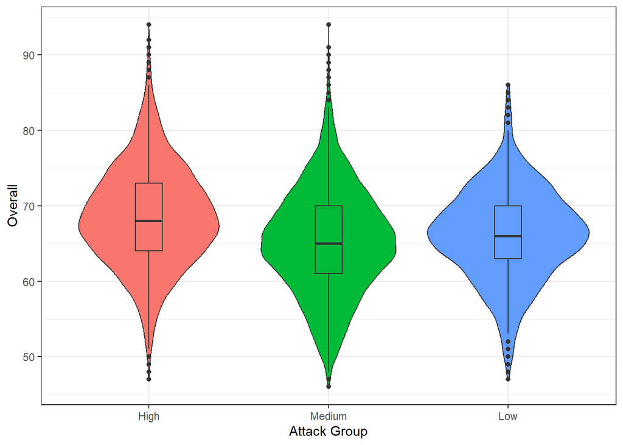

```r
ggplot(data_new_attack, aes(x = attacking_work_rate, y = overall, fill = attacking_work_rate)) +
  geom_violin() +
  geom_boxplot(width = 0.15, position = position_dodge(width = 0.9)) +
  labs(x = "Attack Group", y = "Overall") +
  theme_bw() +
  theme(legend.position = "none")
```

```r
data_at=data_new_attack[sample(nrow(data), 10000), ]
```

```r
set.seed(56)
library(lmPerm)
out_aov_1 <- aovp(formula = overall ~ attacking_work_rate, data = data_at, perm = "Prob")
```

```
## [1] "Settings:  unique SS "
```

```r
summary(out_aov_1)
```

```
## Component 1 :
##                       Df R Sum Sq R Mean Sq Iter  Pr(Prob)
## attacking_work_rate    2    20749   10374.3 5000 < 2.2e-16 ***
## Residuals           9997   465524      46.6
## ---
## Signif. codes:  0 '***' 0.001 '**' 0.01 '*' 0.05 '.' 0.1 ' ' 1
```

> **Nhận xét**
> - p-value<0.05 nên ta bác bỏ giả thuyết H0 và chấp nhận giả thuyết H1. Có ít nhất một nhóm có trung bình overall khác với các nhóm còn lại.

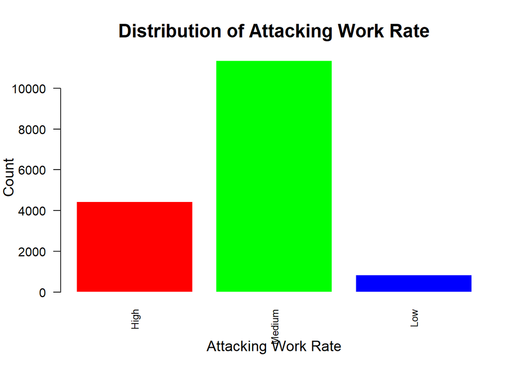

```r
#Vẽ biểu đồ cột
attacking_work_rate_table=with(data_new_attack,table(attacking_work_rate))
barplot(
  attacking_work_rate_table,
  main = "Distribution of Attacking Work Rate", # Tiêu đề biểu đồ
  xlab = "Attacking Work Rate",                  # Nhãn trục X
  ylab = "Count",                     # Nhãn trục Y
  col = rainbow(length(attacking_work_rate_table)),
  border = "white",
  las = 2,
  cex.names = 0.8,
  cex.main = 1.5,
  cex.lab = 1.2
)
```

#### Áp dụng SMOTE

```r
data_new_attack=na.omit(data_new_attack)
```

```r
set.seed(123)

data_new_attack <- smotenc(
  df = data_new_attack,  # Dữ liệu ban đầu
  var = "attacking_work_rate",  # Biến mục tiêu
  k = 5,
  over_ratio = 1  # Tăng cường mẫu lớp thiểu số lên gấp đôi
)
```

```r
# Sử dụng table để xem phân phối các giá trị trong cột
table(data_new_attack$attacking_work_rate)
```

```
##
##   High Medium    Low
##  11360  11360  11360
```

```r
set.seed(42)
train_index <- sample(1:nrow(data_new_attack), size = 0.8 * nrow(data_new_attack))

train_data <- data_new_attack[train_index, ]
test_data <- data_new_attack[-train_index, ]
```

```r
columns <- c("age", "overall", "potential", "value", "wage",
                     "international_reputation", "skill_moves",
                     "body_type", "position", "height",
                    "weight", "crossing", "finishing", "heading_accuracy", "short_passing",
                    "volleys", "dribbling", "curve", "fk_accuracy", "long_passing", "ball_control",
                    "acceleration", "sprint_speed", "agility", "reactions", "balance", "shot_power",
                    "jumping", "stamina", "strength", "long_shots", "aggression", "interceptions",
                    "positioning", "vision", "penalties", "composure", "marking", "standing_tackle",
                    "sliding_tackle","release_clause")
```

#### Hồi quy logistic đa lớp

```r
formula <- as.formula(paste("attacking_work_rate ~", paste(columns, collapse = "+")))
logistic_model=multinom(formula,data=train_data,maxit=200)
summary(logistic_model)
```

```
## Call:
## multinom(formula = formula, data = train_data, maxit = 200)
##
## Coefficients:
##        (Intercept)         age    overall   potential       value       wage
## Medium    7.762729 -0.01439593 0.09769784 -0.01879537 -0.05097818 -0.7041198
## Low       6.403436 -0.01629342 0.10439858 -0.05991415 -0.12573425  3.3877826
##        international_reputation skill_moves2 skill_moves3 skill_moves4
## Medium               0.21875406    -1.283436    -1.274961   -0.9998886
## Low                  0.07695798     6.560495     6.491148    4.1658561
##        skill_moves5 body_typeNormal body_typeStocky positionForward
## Medium   -0.4696506      0.12224398       0.3408450        1.029149
## Low     -15.0126162     -0.03529027      -0.4248504        1.928711
##        positionGoalkeeper positionMidfielder       height      weight
## Medium          11.790666           1.088981  0.004258475 0.001057356
## Low              4.198553           1.412130 -0.078027904 0.002653213
##           crossing   finishing heading_accuracy short_passing     volleys
## Medium -0.01436994 -0.02152988     -0.006282117  0.0003962048 0.002095223
## Low    -0.03243001 -0.04493591      0.025964595  0.0066699398 0.006557993
##          dribbling        curve  fk_accuracy long_passing ball_control
## Medium -0.02579170 -0.001722724 -0.001233288   0.01599177  0.006420667
## Low    -0.04994841  0.008099415 -0.015446309   0.02252748 -0.013353282
##        acceleration sprint_speed     agility  reactions      balance
## Medium  -0.02169993  -0.02967147 0.009283211 0.02160940 -0.003481984
## Low     -0.03170038  -0.04806154 0.011435797 0.02766874 -0.005462034
##         shot_power     jumping     stamina    strength  long_shots  aggression
## Medium -0.01473497 0.001062465 -0.04103883 0.003339537 0.002477987 -0.01435732
## Low    -0.02208519 0.003734264 -0.03598058 0.009460842 0.011814348 -0.01034154
##        interceptions positioning      vision    penalties    composure
## Medium   0.007617563 -0.05658794 -0.01338406 -0.001819165 -0.009737356
## Low      0.049724307 -0.08888012 -0.01192824  0.014484309  0.003926018
##             marking standing_tackle sliding_tackle release_clause
## Medium  0.004155381     0.007703726    -0.01075652    0.017352551
## Low    -0.004765386     0.027859735    -0.00532072    0.003992781
##
## Std. Errors:
##        (Intercept)         age    overall   potential      value         wage
## Medium 0.001639423 0.009643576 0.01214905 0.007630253 0.03699846 0.0007735525
## Low    0.001688457 0.012365442 0.01639529 0.010357502 0.06668340 0.0007926511
##        international_reputation skill_moves2 skill_moves3 skill_moves4
```

[output cut: 14 more lines]

```
##        acceleration sprint_speed     agility   reactions     balance
## Medium  0.004316552  0.004031130 0.003252716 0.004608545 0.002778454
## Low     0.005207733  0.004829219 0.003979085 0.006270602 0.003529953
##         shot_power     jumping     stamina    strength  long_shots  aggression
## Medium 0.003092825 0.002071940 0.002481253 0.002899156 0.003154147 0.002092708
## Low    0.003755089 0.002794601 0.003164696 0.004222599 0.003857912 0.003116899
##        interceptions positioning      vision   penalties   composure
## Medium   0.002943860 0.003339487 0.003594576 0.002742271 0.003692461
## Low      0.004942821 0.003882448 0.004323929 0.003540474 0.004700652
##            marking standing_tackle sliding_tackle release_clause
## Medium 0.002399500     0.004406290    0.004141068     0.01831381
## Low    0.004181525     0.007096297    0.006396032     0.03380075
##
## Residual Deviance: 35481.05
## AIC: 35669.05
```

```r
# Dự đoán lớp cho dữ liệu kiểm tra
pred_class_attack <- predict(logistic_model, newdata = test_data, type = "class")
# Tạo confusion matrix
conf_matrix_attack <- table(test_data$attacking_work_rate, pred_class_attack)
conf_matrix_attack
```

```
##         pred_class_attack
##          High Medium  Low
##   High   1836    332   89
##   Medium  692   1004  587
##   Low      86    196 1994
```

```r
eval_multi_class <- function(x) {
cc <- sum(diag(x))
sc <- sum(x)
pp <- colSums(x)
tt <- rowSums(x)
##
prec <- diag(x)/colSums(x)
recall <- diag(x)/rowSums(x)
macro_prec <- mean(prec)
macro_recall <- mean(recall)
macro_f1 <- 2 * macro_prec * macro_recall/(1/macro_prec + 1/macro_recall)
acc <- cc/sc
kap <- (cc * sc - sum(pp * tt))/(sc**2 - sum(pp * tt))
return(list(Precision = prec, Recall = recall, Accuracy = acc, Kappa = kap,
Macro_F1 = macro_f1))
}
eval_multi_class(conf_matrix_attack)
```

```
## $Precision
##      High    Medium       Low
## 0.7023718 0.6553525 0.7468165
##
## $Recall
##      High    Medium       Low
## 0.8134692 0.4397722 0.8760984
##
## $Accuracy
## [1] 0.7092136
##
## $Kappa
## [1] 0.5639848
##
## $Macro_F1
## [1] 0.3513438
```

> **Nhận xét**
> - Mô hình hồi quy không thật sự tốt khi dự đoán các lớp. Để cải thiện chúng ta sẽ sử dụng mô hình khác như LDA và QDA.

#### LDA

```r
formula <- as.formula(paste("attacking_work_rate ~", paste(columns, collapse = "+")))
# Áp dụng LDA
lda_model <- lda(formula, data = train_data)
# In thông tin mô hình
print(lda_model)
```

```
## Call:
## lda(formula, data = train_data)
##
## Prior probabilities of groups:
##      High    Medium       Low
## 0.3338835 0.3329299 0.3331866
##
## Group means:
##             age  overall potential    value        wage
## High   25.42485 68.50140  72.62793 3.845728 0.014115122
## Medium 24.99119 65.19478  70.62675 1.916438 0.007912416
## Low    26.39184 66.10460  70.06534 1.419909 0.006886690
##        international_reputation skill_moves2 skill_moves3 skill_moves4
## High                   1.159347    0.3156102   0.58112710 0.0999670438
## Medium                 1.094304    0.5054533   0.29370938 0.0313980390
## Low                    1.071568    0.9143549   0.08553501 0.0001100837
##        skill_moves5 body_typeNormal body_typeStocky positionForward
## High    0.003295617       0.5570691      0.04899484      0.29605625
## Medium  0.001432191       0.5975543      0.05938085      0.14850722
## Low     0.000000000       0.6394760      0.05603258      0.01607221
##        positionGoalkeeper positionMidfielder   height   weight crossing
## High            0.0000000          0.4193123 70.43721 161.6152 60.43514
## Medium          0.1680071          0.3731409 71.61760 167.0502 45.94150
## Low             0.0000000          0.2152136 72.62089 172.3935 42.18104
##        finishing heading_accuracy short_passing  volleys dribbling    curve
## High    57.75475         56.63754      65.05069 53.19053  66.97996 58.01154
## Medium  41.34692         49.44001      55.95880 39.23675  51.13308 43.44343
## Low     32.65563         63.66878      58.40720 34.10126  45.98847 38.61110
##        fk_accuracy long_passing ball_control acceleration sprint_speed  agility
## High      51.38448     57.74277     67.35588     74.05262     73.96208 72.21700
## Medium    39.87353     50.62741     54.73317     61.43340     61.53586 60.79244
## Low       36.73462     53.20252     54.76247     56.45108     57.45691 54.41651
##        reactions  balance shot_power  jumping  stamina strength long_shots
## High    64.51011 70.62949   64.86385 66.92278 71.45372 64.75835   58.21188
## Medium  60.70927 61.92751   51.84257 64.31453 59.83893 64.84598   43.04737
## Low     61.11621 56.80189   50.97828 68.52822 65.18909 73.57628   37.54375
##        aggression interceptions positioning   vision penalties composure
## High     59.84433      46.95531    63.16260 60.53958  56.55781  63.27083
## Medium   53.60306      45.36929    45.39099 51.16503  45.42955  56.67280
## Low      66.55071      63.89870    37.44437 44.33216  43.29193  58.70777
```

[output cut: 43 more lines]

```
## long_shots                0.0070443067 -0.0028038217
## aggression               -0.0057341828  0.0135171628
## interceptions             0.0145544121 -0.0009135929
## positioning              -0.0412669901  0.0002027683
## vision                   -0.0041254585 -0.0002534076
## penalties                 0.0060977077  0.0013893886
## composure                 0.0030568115  0.0088087444
## marking                   0.0001390816 -0.0055572339
## standing_tackle           0.0051924434 -0.0028748612
## sliding_tackle           -0.0041666059 -0.0025569629
## release_clause            0.0064231809 -0.0148353222
##
## Proportion of trace:
##    LD1    LD2
## 0.8579 0.1421
```

```r
# Dự đoán trên tập kiểm tra
pred <- predict(lda_model, test_data)

# Đánh giá độ chính xác
confusion_matrix_lda <- table(Predicted = pred$class, Actual = test_data$attacking_work_rate)
accuracy <- sum(diag(confusion_matrix_lda)) / sum(confusion_matrix_lda)
print(confusion_matrix_lda)
```

```
##          Actual
## Predicted High Medium  Low
##    High   1828    718  101
##    Medium  363   1046  327
##    Low      66    519 1848
```

```r
eval_multi_class(confusion_matrix_lda)
```

```
## $Precision
##      High    Medium       Low
## 0.8099247 0.4581691 0.8119508
##
## $Recall
##      High    Medium       Low
## 0.6905931 0.6025346 0.7595561
##
## $Accuracy
## [1] 0.6927817
##
## $Kappa
## [1] 0.5393343
##
## $Macro_F1
## [1] 0.3267524
```

#### QDA

```r
# Áp dụng QDA
qda_model <- qda(attacking_work_rate~age+value+wage+height+weight+crossing + finishing + heading_accuracy + short_passing + volleys + dribbling + curve + fk_accuracy + long_passing + ball_control + acceleration + sprint_speed + agility + reactions + balance + shot_power + jumping + stamina + strength + long_shots + aggression + interceptions + positioning + vision + penalties + composure + marking + standing_tackle + sliding_tackle,
 data = train_data)

# In thông tin mô hình
print(qda_model)
```

```
## Call:
## qda(attacking_work_rate ~ age + value + wage + height + weight +
##     crossing + finishing + heading_accuracy + short_passing +
##     volleys + dribbling + curve + fk_accuracy + long_passing +
##     ball_control + acceleration + sprint_speed + agility + reactions +
##     balance + shot_power + jumping + stamina + strength + long_shots +
##     aggression + interceptions + positioning + vision + penalties +
##     composure + marking + standing_tackle + sliding_tackle, data = train_data)
##
## Prior probabilities of groups:
##      High    Medium       Low
## 0.3338835 0.3329299 0.3331866
##
## Group means:
##             age    value        wage   height   weight crossing finishing
## High   25.42485 3.845728 0.014115122 70.43721 161.6152 60.43514  57.75475
## Medium 24.99119 1.916438 0.007912416 71.61760 167.0502 45.94150  41.34692
## Low    26.39184 1.419909 0.006886690 72.62089 172.3935 42.18104  32.65563
##        heading_accuracy short_passing  volleys dribbling    curve fk_accuracy
## High           56.63754      65.05069 53.19053  66.97996 58.01154    51.38448
## Medium         49.44001      55.95880 39.23675  51.13308 43.44343    39.87353
## Low            63.66878      58.40720 34.10126  45.98847 38.61110    36.73462
##        long_passing ball_control acceleration sprint_speed  agility reactions
## High       57.74277     67.35588     74.05262     73.96208 72.21700  64.51011
## Medium     50.62741     54.73317     61.43340     61.53586 60.79244  60.70927
## Low        53.20252     54.76247     56.45108     57.45691 54.41651  61.11621
##         balance shot_power  jumping  stamina strength long_shots aggression
## High   70.62949   64.86385 66.92278 71.45372 64.75835   58.21188   59.84433
## Medium 61.92751   51.84257 64.31453 59.83893 64.84598   43.04737   53.60306
## Low    56.80189   50.97828 68.52822 65.18909 73.57628   37.54375   66.55071
##        interceptions positioning   vision penalties composure  marking
## High        46.95531    63.16260 60.53958  56.55781  63.27083 47.92771
## Medium      45.36929    45.39099 51.16503  45.42955  56.67280 45.80599
## Low         63.89870    37.44437 44.33216  43.29193  58.70777 63.47825
##        standing_tackle sliding_tackle
## High          47.78637       45.47419
## Medium        46.35518       44.47791
## Low           66.06111       63.48619
```

```r
# Dự đoán trên tập kiểm tra
pred_qda <- predict(qda_model, test_data)

# Đánh giá độ chính xác
confusion_matrix_qda <- table(Predicted = pred_qda$class, Actual = test_data$attacking_work_rate)
accuracy_qda <- sum(diag(confusion_matrix_qda)) / sum(confusion_matrix_qda)
print(confusion_matrix_qda)
```

```
##          Actual
## Predicted High Medium  Low
##    High   1734    705   94
##    Medium  268    915  137
##    Low     255    663 2045
```

```r
eval_multi_class(confusion_matrix_qda)
```

```
## $Precision
##      High    Medium       Low
## 0.7682765 0.4007884 0.8985062
##
## $Recall
##      High    Medium       Low
## 0.6845638 0.6931818 0.6901789
##
## $Accuracy
## [1] 0.6886737
##
## $Kappa
## [1] 0.5331857
##
## $Macro_F1
## [1] 0.3274379
```

> **Nhận xét** - các mô hình LDA và QDA cho kết quả tương tự so với mô hình hồi quy đa lớp. - Các mô hình phân loại hoạt động không thực sự tốt đối với biến attacking_work_rate.Chúng ta có thể nói rằng các biến không thực sự giải thích được attacking_work_rate

## Phòng thủ

### A/B Testing

> - Giả thuyết H0:các nhóm cầu thủ có cùng xu hướng di chuyển thì có trung bình overall như nhau.
> - Đối thuyết H1: Ít nhất có một nhóm có trung bình overall khác với những nhóm còn lại.

```r
set.seed(123)
# Lựa chọn các cột cần thiết để tạo ra một data frame mới
data_new_defensive <- data[, sapply(data, function(col) is.numeric(col) || is.factor(col))]
glimpse(data_new_defensive)
```

```
## Rows: 16,643
## Columns: 52
## $ id                       <int> 158023, 20801, 190871, 193080, 192985, 183277…
## $ age                      <int> 31, 33, 26, 27, 27, 27, 32, 31, 32, 25, 29, 2…
## $ overall                  <int> 94, 94, 92, 91, 91, 91, 91, 91, 91, 90, 90, 9…
## $ potential                <int> 94, 94, 93, 93, 92, 91, 91, 91, 91, 93, 90, 9…
## $ value                    <dbl> 110.5, 77.0, 118.5, 72.0, 102.0, 93.0, 67.0, …
## $ wage                     <dbl> 0.565, 0.405, 0.290, 0.260, 0.355, 0.340, 0.4…
## $ preferred_foot           <fct> Left, Right, Right, Right, Right, Right, Righ…
## $ international_reputation <int> 5, 5, 5, 4, 4, 4, 4, 5, 4, 3, 4, 4, 3, 4, 3, …
## $ weak_foot                <fct> 4, 4, 5, 3, 5, 4, 4, 4, 3, 3, 4, 5, 3, 2, 3, …
## $ skill_moves              <fct> 4, 5, 5, 1, 4, 4, 4, 3, 3, 1, 4, 3, 2, 4, 2, …
## $ attacking_work_rate      <fct> Medium, High, High, Medium, High, High, High,…
## $ defensive_work_rate      <fct> Medium, Low, Medium, Medium, High, Medium, Hi…
## $ body_type                <fct> Lean, Stocky, Lean, Lean, Normal, Normal, Lea…
```

[output cut: 39 more lines]

```r
data_new_defensive|>group_by(defensive_work_rate)|>
  summarise(n=n(),mean=mean(overall))
```

```
## # A tibble: 3 × 3
##   defensive_work_rate     n  mean
##   <fct>               <int> <dbl>
## 1 High                 2907  68.8
## 2 Medium              12318  65.4
## 3 Low                  1418  67.2
```

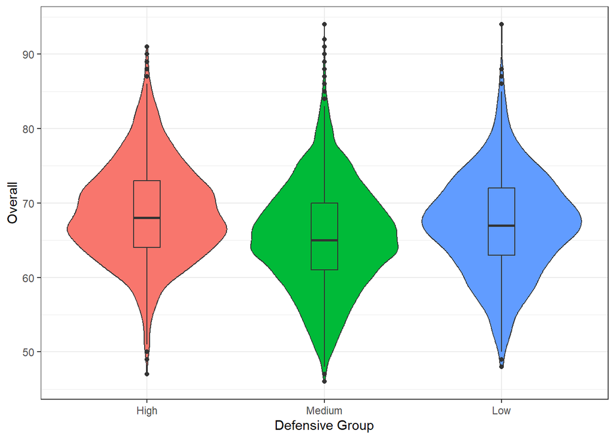

```r
ggplot(data_new_defensive, aes(x = defensive_work_rate, y = overall, fill = defensive_work_rate)) +
  geom_violin() +
  geom_boxplot(width = 0.15, position = position_dodge(width = 0.9)) +
  labs(x = "Defensive Group", y = "Overall") +
  theme_bw() +
  theme(legend.position = "none")
```

```r
data_def=data_new_defensive[sample(nrow(data), 10000), ]
```

```r
set.seed(56)
library(lmPerm)
out_aov_1 <- aovp(formula = overall ~ defensive_work_rate, data = data_def, perm = "Prob")
```

```
## [1] "Settings:  unique SS "
```

```r
summary(out_aov_1)
```

```
## Component 1 :
##                       Df R Sum Sq R Mean Sq Iter  Pr(Prob)
## defensive_work_rate    2    16214    8107.1 5000 < 2.2e-16 ***
## Residuals           9997   470058      47.0
## ---
## Signif. codes:  0 '***' 0.001 '**' 0.01 '*' 0.05 '.' 0.1 ' ' 1
```

> **Nhận xét**
> - p-value<0.05 nên ta bác bỏ giả thuyết H0 và chấp nhận giả thuyết H1. Có ít nhất một nhóm có trung bình overall khác với các nhóm còn lại.

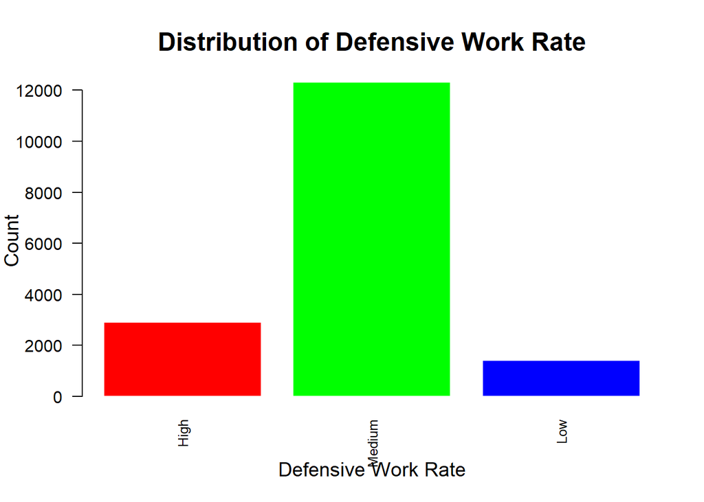

```r
#Vẽ biểu đồ cột
defensive_work_rate_table=with(data_new_defensive,table(defensive_work_rate))
barplot(
  defensive_work_rate_table,
  main = "Distribution of Defensive Work Rate", # Tiêu đề biểu đồ
  xlab = "Defensive Work Rate",                  # Nhãn trục X
  ylab = "Count",                     # Nhãn trục Y
  col = rainbow(length(defensive_work_rate_table)),
  border = "white",
  las = 2,
  cex.names = 0.8,
  cex.main = 1.5,
  cex.lab = 1.2
)
```

```r
data_new_defensive=na.omit(data_new_defensive)
```

```r
set.seed(123)
# Áp dụng SMOTE
data_new_defensive <- smotenc(
  df = data_new_defensive,  # Dữ liệu ban đầu
  var = "defensive_work_rate",  # Biến mục tiêu
  k = 5,
  over_ratio = 1  # Tăng cường mẫu lớp thiểu số lên gấp đôi
)
```

```r
# Sử dụng table để xem phân phối các giá trị trong cột
table(data_new_defensive$defensive_work_rate)
```

```
##
##   High Medium    Low
##  12318  12318  12318
```

```r
set.seed(42)
train_index <- sample(1:nrow(data_new_defensive), size = 0.8 * nrow(data_new_defensive))

train_data <- data_new_defensive[train_index, ]
test_data <- data_new_defensive[-train_index, ]
```

```r
columns <- c("age", "overall", "potential", "value", "wage",
                     "international_reputation", "skill_moves",
                     "body_type", "position", "height",
                    "weight", "crossing", "finishing", "heading_accuracy", "short_passing",
                    "volleys", "dribbling", "curve", "fk_accuracy", "long_passing", "ball_control",
                    "acceleration", "sprint_speed", "agility", "reactions", "balance", "shot_power",
                    "jumping", "stamina", "strength", "long_shots", "aggression", "interceptions",
                    "positioning", "vision", "penalties", "composure", "marking", "standing_tackle",
                    "sliding_tackle","release_clause")
```

### Hồi quy logistic đa lớp

```r
formula <- as.formula(paste("defensive_work_rate ~ ", paste(columns, collapse = "+")))
logistic_model=multinom(formula,data=train_data,maxit=200)
summary(logistic_model)
```

```
## Call:
## multinom(formula = formula, data = train_data, maxit = 200)
##
## Coefficients:
##        (Intercept)         age    overall   potential       value      wage
## Medium    5.015375 -0.02358289 0.01755786 -0.01623050 0.009372469 -5.865956
## Low       5.483021 -0.00852905 0.06825562 -0.04880634 0.038979353 -8.871347
##        international_reputation skill_moves2 skill_moves3 skill_moves4
## Medium               0.09959169    -1.790292    -1.576350    -1.506949
## Low                  0.28199311     1.815906     2.111098     1.993594
##        skill_moves5 body_typeNormal body_typeStocky positionForward
## Medium    -1.045337       0.1485668       0.4028768      -0.6348254
## Low        2.520201       0.1585130      -0.3036416      -0.9808372
##        positionGoalkeeper positionMidfielder     height        weight
## Medium          10.934303         -0.7404849 0.08353516 -0.0053794464
## Low             -2.957778         -0.8870787 0.01391811 -0.0005423542
##            crossing    finishing heading_accuracy short_passing     volleys
## Medium  0.003284327 -0.005647297    -0.0064540737   -0.01401433 -0.01444795
## Low    -0.007738851 -0.002371134     0.0004198295   -0.01991215 -0.02056989
##          dribbling       curve fk_accuracy long_passing ball_control
## Medium 0.002719449 0.008433454 0.009467121  0.006713140   0.03397636
## Low    0.016894602 0.021140874 0.011217450  0.009188508   0.04136322
##        acceleration sprint_speed     agility    reactions      balance
## Medium -0.004802287  0.009834281 0.001669992  0.005350687  0.001242016
## Low    -0.006885682  0.017084616 0.009151872 -0.019180971 -0.011853164
##          shot_power     jumping     stamina     strength  long_shots
## Medium  0.003684318 -0.01108234 -0.05316451 -0.013174535 0.001720308
## Low    -0.000476902 -0.01155110 -0.07580236 -0.005835046 0.008331054
##         aggression interceptions positioning       vision   penalties
## Medium -0.04250571  -0.007036528  0.00791972 -0.004600203 0.005954411
## Low    -0.04868462  -0.015696016  0.02049902  0.015759157 0.016584267
##           composure     marking standing_tackle sliding_tackle release_clause
## Medium -0.016692310 -0.01830737     -0.02909940     0.02384957    0.004041464
## Low    -0.009211799 -0.04564526     -0.06311099     0.02210910   -0.025170313
##
## Std. Errors:
##        (Intercept)         age    overall   potential      value        wage
## Medium 0.003484913 0.009158527 0.01125020 0.007846819 0.03273284 0.001164610
## Low    0.003414577 0.011293307 0.01487629 0.009506042 0.03788344 0.001193228
##        international_reputation skill_moves2 skill_moves3 skill_moves4
```

[output cut: 14 more lines]

```
##        acceleration sprint_speed     agility   reactions     balance
## Medium  0.003778958  0.003450003 0.002928238 0.004653905 0.002601828
## Low     0.004973903  0.004572388 0.003877762 0.005620073 0.003311543
##         shot_power     jumping     stamina    strength  long_shots  aggression
## Medium 0.002719783 0.002038915 0.002394697 0.003064661 0.002813008 0.002241874
## Low    0.004090672 0.002479803 0.002970273 0.003609598 0.003942254 0.002523599
##        interceptions positioning      vision   penalties   composure
## Medium   0.003302696 0.002725310 0.003108177 0.002546015 0.003483137
## Low      0.003475196 0.004194927 0.004344163 0.003369387 0.004500740
##            marking standing_tackle sliding_tackle release_clause
## Medium 0.002738363     0.004900258    0.004417113     0.01634815
## Low    0.002851380     0.005208584    0.004875592     0.01921766
##
## Residual Deviance: 40643.12
## AIC: 40831.12
```

```r
# Dự đoán lớp cho dữ liệu kiểm tra
pred_class_defensive <- predict(logistic_model, newdata = test_data, type = "class")
# Tạo confusion matrix
conf_matrix_defensive <- table(test_data$defensive_work_rate, pred_class_defensive)
conf_matrix_defensive
```

```
##         pred_class_defensive
##          High Medium  Low
##   High   1994    376  168
##   Medium  745   1071  643
##   Low      95    226 2073
```

```r
eval_multi_class(conf_matrix_defensive)
```

```
## $Precision
##      High    Medium       Low
## 0.7035992 0.6401674 0.7187933
##
## $Recall
##      High    Medium       Low
## 0.7856580 0.4355429 0.8659148
##
## $Accuracy
## [1] 0.6951698
##
## $Kappa
## [1] 0.5427304
##
## $Macro_F1
## [1] 0.3307945
```

**Nhận xét** Mô hình hồi quy không thật sự tốt khi dự đoán các lớp. Để cải thiện chúng ta sẽ sử dụng mô hình khác như LDA và QDA.

### LDA

```r
formula <- as.formula(paste("defensive_work_rate ~", paste(columns, collapse = "+")))
# Áp dụng LDA
lda_model <- lda(formula, data = train_data)
# In thông tin mô hình
print(lda_model)
```

```
## Call:
## lda(formula, data = train_data)
##
## Prior probabilities of groups:
##      High    Medium       Low
## 0.3308189 0.3334912 0.3356899
##
## Group means:
##             age  overall potential    value        wage
## High   26.38141 68.68828  72.06947 3.397403 0.014157008
## Medium 24.88863 65.42804  70.83457 2.125620 0.008364946
## Low    25.47889 67.06637  71.47422 2.621207 0.009447228
##        international_reputation skill_moves2 skill_moves3 skill_moves4
## High                   1.164253    0.6212679    0.3453988   0.03231084
## Medium                 1.093721    0.4637387    0.3351253   0.04462927
## Low                    1.146903    0.2998791    0.5921000   0.10378879
##        skill_moves5 body_typeNormal body_typeStocky positionForward
## High    0.001022495       0.6279141      0.06022495      0.08159509
## Medium  0.001927173       0.5876864      0.05669946      0.16695405
## Low     0.004232164       0.5816203      0.04151552      0.51692866
##        positionGoalkeeper positionMidfielder  height   weight crossing
## High            0.0000000          0.4505112 71.5448 167.9477 53.69665
## Medium          0.1545796          0.3510498 71.4256 165.9244 47.90963
## Low             0.0000000          0.4441757 70.5016 162.4609 55.58430
##        finishing heading_accuracy short_passing  volleys dribbling    curve
## High    45.65352         61.35415      64.74955 44.37282  58.48503 49.30234
## Medium  43.13176         49.48504      56.55574 40.64956  52.93650 45.22193
## Low     63.05511         56.20895      62.65300 57.00264  66.70478 57.46142
##        fk_accuracy long_passing ball_control acceleration sprint_speed  agility
## High      45.23868     59.51249     63.13642     65.24203     65.68727 64.17484
## Medium    41.15509     50.90070     55.92180     63.46141     63.54671 62.33127
## Low       51.45178     53.62976     66.80824     71.78658     71.61504 71.15174
##        reactions  balance shot_power  jumping  stamina strength long_shots
## High    64.94503 64.40000   59.81905 69.94866 73.09700 71.60794   50.11902
## Medium  60.92626 63.17984   52.99158 64.20469 60.73618 64.12719   44.50157
## Low     62.44165 69.19654   65.68617 64.53718 63.72662 63.03472   60.09535
##        aggression interceptions positioning   vision penalties composure
## High     69.28044      62.19027    51.89749 55.34752  49.72493  63.19224
## Medium   53.34456      44.77868    47.46090 52.01866  46.57521  57.03956
## Low      50.81405      31.86200    64.09604 60.07773  61.02386  61.83334
```

[output cut: 43 more lines]

```
## long_shots                0.0017614153  0.0041196174
## aggression               -0.0185451674  0.0142345154
## interceptions            -0.0084297622 -0.0001264885
## positioning               0.0051832360 -0.0159048463
## vision                    0.0024174231  0.0019773120
## penalties                 0.0066730984 -0.0012001854
## composure                -0.0020812277  0.0143715578
## marking                  -0.0234572681 -0.0043532273
## standing_tackle          -0.0340211551 -0.0114980378
## sliding_tackle            0.0038128279 -0.0047315021
## release_clause           -0.0059697623 -0.0115286630
##
## Proportion of trace:
##    LD1    LD2
## 0.8439 0.1561
```

```r
# Dự đoán trên tập kiểm tra
pred <- predict(lda_model, test_data)

# Đánh giá độ chính xác
confusion_matrix_lda <- table(Predicted = pred$class, Actual = test_data$defensive_work_rate)
accuracy <- sum(diag(confusion_matrix_lda)) / sum(confusion_matrix_lda)
print(confusion_matrix_lda)
```

```
##          Actual
## Predicted High Medium  Low
##    High   2019    806   91
##    Medium  323    991  212
##    Low     196    662 2091
```

```r
eval_multi_class(confusion_matrix_lda)
```

```
## $Precision
##      High    Medium       Low
## 0.7955083 0.4030094 0.8734336
##
## $Recall
##      High    Medium       Low
## 0.6923868 0.6494102 0.7090539
##
## $Accuracy
## [1] 0.6901637
##
## $Kappa
## [1] 0.5351921
##
## $Macro_F1
## [1] 0.324415
```

### QDA

```r
# Áp dụng QDA
qda_model <- qda(defensive_work_rate~age+value+wage+height+weight+crossing + finishing + heading_accuracy + short_passing + volleys + dribbling + curve + fk_accuracy + long_passing + ball_control + acceleration + sprint_speed + agility + reactions + balance + shot_power + jumping + stamina + strength + long_shots + aggression + interceptions + positioning + vision + penalties + composure + marking + standing_tackle + sliding_tackle,
 data = train_data)

# In thông tin mô hình
print(qda_model)
```

```
## Call:
## qda(defensive_work_rate ~ age + value + wage + height + weight +
##     crossing + finishing + heading_accuracy + short_passing +
##     volleys + dribbling + curve + fk_accuracy + long_passing +
##     ball_control + acceleration + sprint_speed + agility + reactions +
##     balance + shot_power + jumping + stamina + strength + long_shots +
##     aggression + interceptions + positioning + vision + penalties +
##     composure + marking + standing_tackle + sliding_tackle, data = train_data)
##
## Prior probabilities of groups:
##      High    Medium       Low
## 0.3308189 0.3334912 0.3356899
##
## Group means:
##             age    value        wage  height   weight crossing finishing
## High   26.38141 3.397403 0.014157008 71.5448 167.9477 53.69665  45.65352
## Medium 24.88863 2.125620 0.008364946 71.4256 165.9244 47.90963  43.13176
## Low    25.47889 2.621207 0.009447228 70.5016 162.4609 55.58430  63.05511
##        heading_accuracy short_passing  volleys dribbling    curve fk_accuracy
## High           61.35415      64.74955 44.37282  58.48503 49.30234    45.23868
## Medium         49.48504      56.55574 40.64956  52.93650 45.22193    41.15509
## Low            56.20895      62.65300 57.00264  66.70478 57.46142    51.45178
##        long_passing ball_control acceleration sprint_speed  agility reactions
## High       59.51249     63.13642     65.24203     65.68727 64.17484  64.94503
## Medium     50.90070     55.92180     63.46141     63.54671 62.33127  60.92626
## Low        53.62976     66.80824     71.78658     71.61504 71.15174  62.44165
##         balance shot_power  jumping  stamina strength long_shots aggression
## High   64.40000   59.81905 69.94866 73.09700 71.60794   50.11902   69.28044
## Medium 63.17984   52.99158 64.20469 60.73618 64.12719   44.50157   53.34456
## Low    69.19654   65.68617 64.53718 63.72662 63.03472   60.09535   50.81405
##        interceptions positioning   vision penalties composure  marking
## High        62.19027    51.89749 55.34752  49.72493  63.19224 61.68116
## Medium      44.77868    47.46090 52.01866  46.57521  57.03956 45.39974
## Low         31.86200    64.09604 60.07773  61.02386  61.83334 33.96625
##        standing_tackle sliding_tackle
## High          63.59717       60.79931
## Medium        45.86449       44.03378
## Low           31.37348       29.30862
```

```r
# Dự đoán trên tập kiểm tra
pred_qda <- predict(qda_model, test_data)

# Đánh giá độ chính xác
confusion_matrix_qda <- table(Predicted = pred_qda$class, Actual = test_data$defensive_work_rate)
accuracy_qda <- sum(diag(confusion_matrix_qda)) / sum(confusion_matrix_qda)
print(confusion_matrix_qda)
```

```
##          Actual
## Predicted High Medium  Low
##    High   2004    805  130
##    Medium  241    985  122
##    Low     293    669 2142
```

```r
eval_multi_class(confusion_matrix_qda)
```

```
## $Precision
##      High    Medium       Low
## 0.7895981 0.4005693 0.8947368
##
## $Recall
##      High    Medium       Low
## 0.6818646 0.7307122 0.6900773
##
## $Accuracy
## [1] 0.6942227
##
## $Kappa
## [1] 0.5413853
##
## $Macro_F1
## [1] 0.3399486
```

[output not shown]